# Introdução ao R - Sessão 5 e 6

Medidas de associação entre variáveis e GLM

Tiago Ferreira

Novembro 18, 2020

AGENDA | Medidas de associação entre variáveis e GLM

**1. Associação entre fatores**  
**2. Associação entre variáveis contínuas**  
**3. Comparações de médias**  
**4. O “General Linear Model” (GLM)**  
**5. Análise de regressão**  
**6. Análise de variância**

```r
load("coffee.RData")

head(coffee)
```

```
##                       coffee_shop_name cityarea num_reviews popular rating
## 1               Manana Coffee & Juice  downtown          33   FALSE   4.85
## 2                        Brian's Brew  downtown          45   FALSE   4.84
## 3                       Flitch Coffee  downtown          28   FALSE   4.82
## 4 Third Coast Coffee Roasting Company  downtown          56   FALSE   4.82
## 5                    Kowabunga Coffee  downtown          16   FALSE   4.81
## 6                       Legend Coffee  downtown          28   FALSE   4.71
##   ratingMorning ratingLunch ratingAfternoon ratingDinner coffee coffee_rec  tea
## 1      5.288560    5.039455        5.261275     4.375693   0.67         Ok 0.03
## 2      4.795201    4.591020        4.517394     4.295209   0.89  Very Good 0.00
## 3      4.990468    4.166708        4.506920     5.154803   0.57         Ok 0.07
## 4      4.889728    4.389281        4.312029     3.951514   0.75       Good 0.00
## 5      4.428808    5.092333        4.504868     5.195638   0.06   Very Bad 0.13
## 6      5.093832    4.571647        4.988562     4.425626   0.89  Very Good 0.04
##     tea_rec food food_rec alcohol alcohol_rec vibe vibe_rec service service_rec
## 1        Ok 0.21       Ok    0.00          Ok 0.52     Good    0.27          Ok
## 2       Bad 0.11       Ok    0.00          Ok 0.04       Ok    0.22         Bad
## 3      Good 0.00 Very Bad    0.00          Ok 0.46     Good    0.29          Ok
## 4       Bad 0.04      Bad    0.04        Good 0.16       Ok    0.21         Bad
## 5 Very Good 0.00 Very Bad    0.00          Ok 0.00       Ok    0.44        Good
## 6        Ok 0.18       Ok    0.00          Ok 0.00       Ok    0.39          Ok
##   price price_rec convenience convenience_rec internet seating
## 1 -0.06  Very Bad      0.0375              Ok    FALSE    TRUE
## 2  0.00        Ok      0.0375              Ok    FALSE    TRUE
## 3  0.04      Good      0.0725            Good    FALSE    TRUE
## 4  0.18 Very Good      0.0500              Ok    FALSE   FALSE
## 5  0.00        Ok      0.1575       Very Good    FALSE   FALSE
## 6  0.04      Good      0.0725            Good    FALSE   FALSE
```

```r
summary(coffee)
```

```
##  coffee_shop_name       cityarea   num_reviews     popular
##  Length:67          downtown:24   Min.   :  0.0   Mode :logical
##  Class :character   eastcity:28   1st Qu.: 96.0   FALSE:59
##  Mode  :character   westcity:15   Median :100.0   TRUE :8
##                                   Mean   :100.6
##                                   3rd Qu.:100.0
##                                   Max.   :400.0
##      rating      ratingMorning    ratingLunch    ratingAfternoon
##  Min.   :3.370   Min.   :3.101   Min.   :2.548   Min.   :2.977
##  1st Qu.:3.985   1st Qu.:3.928   1st Qu.:3.871   1st Qu.:3.976
##  Median :4.260   Median :4.168   Median :4.264   Median :4.255
##  Mean   :4.232   Mean   :4.229   Mean   :4.250   Mean   :4.225
##  3rd Qu.:4.435   3rd Qu.:4.527   3rd Qu.:4.604   3rd Qu.:4.503
##  Max.   :4.850   Max.   :5.289   Max.   :5.395   Max.   :5.261
##   ratingDinner       coffee           coffee_rec      tea
##  Min.   :2.862   Min.   :0.0600   Very Bad : 4   Min.   :-0.04000
##  1st Qu.:3.864   1st Qu.:0.3850   Bad      :13   1st Qu.: 0.00500
##  Median :4.295   Median :0.5600   Ok       :33   Median : 0.03000
##  Mean   :4.273   Mean   :0.5544   Good     :13   Mean   : 0.04288
##  3rd Qu.:4.677   3rd Qu.:0.7050   Very Good: 4   3rd Qu.: 0.05000
##  Max.   :5.455   Max.   :1.0000                  Max.   : 0.51000
##       tea_rec        food             food_rec     alcohol
##  Very Bad : 3   Min.   :0.0000   Very Bad : 4   Min.   :-0.01000
##  Bad      :14   1st Qu.:0.1100   Bad      : 9   1st Qu.: 0.00000
##  Ok       :32   Median :0.2000   Ok       :37   Median : 0.00000
##  Good     :13   Mean   :0.2967   Good     :13   Mean   : 0.03863
##  Very Good: 5   3rd Qu.:0.4100   Very Good: 4   3rd Qu.: 0.03421
##                 Max.   :0.9200                  Max.   : 0.47000
##     alcohol_rec      vibe             vibe_rec     service          service_rec
##  Very Bad : 3   Min.   :0.0000   Very Bad : 0   Min.   :0.0500   Very Bad : 4
##  Bad      : 0   1st Qu.:0.0000   Bad      : 0   1st Qu.:0.2500   Bad      :13
##  Ok       :47   Median :0.2193   Ok       :49   Median :0.3200   Ok       :31
##  Good     :11   Mean   :0.2194   Good     :14   Mean   :0.3224   Good     :15
##  Very Good: 6   3rd Qu.:0.4000   Very Good: 4   3rd Qu.:0.4000   Very Good: 4
##                 Max.   :0.7500                  Max.   :0.6200
##      price              price_rec   convenience        convenience_rec
##  Min.   :-0.16000   Very Bad : 4   Min.   :-0.01000   Very Bad : 3
##  1st Qu.:-0.01000   Bad      : 8   1st Qu.: 0.03000   Bad      :12
##  Median : 0.02000   Ok       :34   Median : 0.04750   Ok       :34
##  Mean   : 0.02318   Good     :17   Mean   : 0.04901   Good     :14
##  3rd Qu.: 0.04000   Very Good: 4   3rd Qu.: 0.06000   Very Good: 4
##  Max.   : 0.20000                  Max.   : 0.15750
##   internet        seating
##  Mode :logical   Mode :logical
##  FALSE:28        FALSE:7
##  TRUE :39        TRUE :60
##
##
##
```

```r
names(coffee)
```

```
##  [1] "coffee_shop_name" "cityarea"         "num_reviews"      "popular"
##  [5] "rating"           "ratingMorning"    "ratingLunch"      "ratingAfternoon"
##  [9] "ratingDinner"     "coffee"           "coffee_rec"       "tea"
## [13] "tea_rec"          "food"             "food_rec"         "alcohol"
## [17] "alcohol_rec"      "vibe"             "vibe_rec"         "service"
## [21] "service_rec"      "price"            "price_rec"        "convenience"
## [25] "convenience_rec"  "internet"         "seating"
```

# 1. Associação entre fatores

## Tabelas de contingência

As tabelas de contingências permitem sumariar frequências relativas entre categorias de duas ou mais variáveis categoriais (ou fatores), possibilitando uma análise da associação entre essas variáveis. No R, as tabelas de contingências são simples extensões das tabelas de frequências, sendo criadas pelo mesmo grupo de funções (i.e., **table** e **xtabs**).

### A função **table()** para tabelas de contingência

```r
# two way table using table()
mytable1 <- with(coffee, table(coffee_rec, tea_rec))
mytable1  # frequencies
```

```
##            tea_rec
## coffee_rec  Very Bad Bad Ok Good Very Good
##   Very Bad         0   2  1    0         1
##   Bad              1   3  7    1         1
##   Ok               2   4 17    8         2
##   Good             0   3  6    4         0
##   Very Good        0   2  1    0         1
```

```r
prop.table(mytable1) # proportions
```

```
##            tea_rec
## coffee_rec    Very Bad        Bad         Ok       Good  Very Good
##   Very Bad  0.00000000 0.02985075 0.01492537 0.00000000 0.01492537
##   Bad       0.01492537 0.04477612 0.10447761 0.01492537 0.01492537
##   Ok        0.02985075 0.05970149 0.25373134 0.11940299 0.02985075
##   Good      0.00000000 0.04477612 0.08955224 0.05970149 0.00000000
##   Very Good 0.00000000 0.02985075 0.01492537 0.00000000 0.01492537
```

```r
prop.table(mytable1)*100 # percentages
```

```
##            tea_rec
## coffee_rec   Very Bad       Bad        Ok      Good Very Good
##   Very Bad   0.000000  2.985075  1.492537  0.000000  1.492537
##   Bad        1.492537  4.477612 10.447761  1.492537  1.492537
##   Ok         2.985075  5.970149 25.373134 11.940299  2.985075
##   Good       0.000000  4.477612  8.955224  5.970149  0.000000
##   Very Good  0.000000  2.985075  1.492537  0.000000  1.492537
```

### A função **xtabs()** para tabelas de contigências

Para criar uma tabela de contingência usando a função **xtabs** a, as variáveis a serem “cruzadas” devem surgir do lado direito da fórmula (**~**).

```r
#1. Creates table
mytable2 <- xtabs(num_reviews ~ coffee_rec + tea_rec, data = coffee)
#2. Presents table
mytable2 # frequencies
```

```
##            tea_rec
## coffee_rec  Very Bad  Bad   Ok Good Very Good
##   Very Bad         0  200  100    0        16
##   Bad            100  229  876  244       100
##   Ok             225  473 1533 1128       204
##   Good             0  219  582  283         0
##   Very Good        0  102   28    0       100
```

```r
#3. Displays row sums
margin.table(mytable2, 1)
```

```
## coffee_rec
##  Very Bad       Bad        Ok      Good Very Good
##       316      1549      3563      1084       230
```

```r
#4. Displays column sums
margin.table(mytable2, 2)
```

```
## tea_rec
##  Very Bad       Bad        Ok      Good Very Good
##       325      1223      3119      1655       420
```

```r
#5 Adds row and column sums to the table
addmargins(mytable2)
```

```
##            tea_rec
## coffee_rec  Very Bad  Bad   Ok Good Very Good  Sum
##   Very Bad         0  200  100    0        16  316
##   Bad            100  229  876  244       100 1549
##   Ok             225  473 1533 1128       204 3563
##   Good             0  219  582  283         0 1084
##   Very Good        0  102   28    0       100  230
##   Sum            325 1223 3119 1655       420 6742
```

```r
#6 cell proportions
prop.table(mytable2)
```

```
##            tea_rec
## coffee_rec     Very Bad         Bad          Ok        Good   Very Good
##   Very Bad  0.000000000 0.029664788 0.014832394 0.000000000 0.002373183
##   Bad       0.014832394 0.033966182 0.129931771 0.036191041 0.014832394
##   Ok        0.033372886 0.070157223 0.227380599 0.167309404 0.030258084
##   Good      0.000000000 0.032482943 0.086324533 0.041975675 0.000000000
##   Very Good 0.000000000 0.015129042 0.004153070 0.000000000 0.014832394
```

```r
#7 row proportions
prop.table(mytable2, 1)
```

```
##            tea_rec
## coffee_rec    Very Bad        Bad         Ok       Good  Very Good
##   Very Bad  0.00000000 0.63291139 0.31645570 0.00000000 0.05063291
##   Bad       0.06455778 0.14783731 0.56552615 0.15752098 0.06455778
##   Ok        0.06314903 0.13275330 0.43025540 0.31658715 0.05725512
##   Good      0.00000000 0.20202952 0.53690037 0.26107011 0.00000000
##   Very Good 0.00000000 0.44347826 0.12173913 0.00000000 0.43478261
```

```r
#8 column proportions
prop.table(mytable2, 2)
```

```
##            tea_rec
## coffee_rec     Very Bad         Bad          Ok        Good   Very Good
##   Very Bad  0.000000000 0.163532298 0.032061558 0.000000000 0.038095238
##   Bad       0.307692308 0.187244481 0.280859250 0.147432024 0.238095238
##   Ok        0.692307692 0.386753884 0.491503687 0.681570997 0.485714286
##   Good      0.000000000 0.179067866 0.186598269 0.170996979 0.000000000
##   Very Good 0.000000000 0.083401472 0.008977236 0.000000000 0.238095238
```

```r
#9 cell and column proportion with row and column margins
addmargins(prop.table(mytable2))
```

```
##            tea_rec
## coffee_rec     Very Bad         Bad          Ok        Good   Very Good
##   Very Bad  0.000000000 0.029664788 0.014832394 0.000000000 0.002373183
##   Bad       0.014832394 0.033966182 0.129931771 0.036191041 0.014832394
##   Ok        0.033372886 0.070157223 0.227380599 0.167309404 0.030258084
##   Good      0.000000000 0.032482943 0.086324533 0.041975675 0.000000000
##   Very Good 0.000000000 0.015129042 0.004153070 0.000000000 0.014832394
##   Sum       0.048205280 0.181400178 0.462622367 0.245476120 0.062296055
##            tea_rec
## coffee_rec          Sum
##   Very Bad  0.046870365
##   Bad       0.229753782
##   Ok        0.528478196
##   Good      0.160783150
##   Very Good 0.034114506
##   Sum       1.000000000
```

Se na formula de xtabs() uma outra variável é incluída no lado esquerdo da formula (~), essa variável é tratada como um vetor com frequências a incluir na tabela de contingências.

```r
paste("The total number of reviews is", sum(coffee$num_reviews), sep=": ")
```

```
## [1] "The total number of reviews is: 6742"
```

```r
mytable3 <- xtabs(num_reviews ~ coffee_rec + tea_rec, data = coffee)
mytable3
```

```
##            tea_rec
## coffee_rec  Very Bad  Bad   Ok Good Very Good
##   Very Bad         0  200  100    0        16
##   Bad            100  229  876  244       100
##   Ok             225  473 1533 1128       204
##   Good             0  219  582  283         0
##   Very Good        0  102   28    0       100
```

```r
sum(mytable3)
```

```
## [1] 6742
```

### Tabelas de contigências com 3 ou mais variáveis

```r
#1. Creates a three-way table
mytable4 <- xtabs(~ coffee_rec + internet + cityarea, data=coffee)
#2. Presents table
mytable4
```

```
## , , cityarea = downtown
##
##            internet
## coffee_rec  FALSE TRUE
##   Very Bad      2    0
##   Bad           4    0
##   Ok            4    5
##   Good          3    3
##   Very Good     2    1
##
## , , cityarea = eastcity
##
##            internet
## coffee_rec  FALSE TRUE
##   Very Bad      0    2
##   Bad           4    2
##   Ok            4    9
##   Good          0    6
##   Very Good     0    1
##
## , , cityarea = westcity
##
##            internet
## coffee_rec  FALSE TRUE
##   Very Bad      0    0
##   Bad           1    2
##   Ok            4    7
##   Good          0    1
##   Very Good     0    0
```

```r
#3. Prints table in compact format
ftable(mytable4)
```

```
##                     cityarea downtown eastcity westcity
## coffee_rec internet
## Very Bad   FALSE                    2        0        0
##            TRUE                     0        2        0
## Bad        FALSE                    4        4        1
##            TRUE                     0        2        2
## Ok         FALSE                    4        4        4
##            TRUE                     5        9        7
## Good       FALSE                    3        0        0
##            TRUE                     3        6        1
## Very Good  FALSE                    2        0        0
##            TRUE                     1        1        0
```

```r
#4 Table percentage (2 decimals) of coffee categories for internet and city area with marginal sums
round(ftable(addmargins(prop.table(mytable4)))*100, 2)
```

```
##                     cityarea downtown eastcity westcity    Sum
## coffee_rec internet
## Very Bad   FALSE                 2.99     0.00     0.00   2.99
##            TRUE                  0.00     2.99     0.00   2.99
##            Sum                   2.99     2.99     0.00   5.97
## Bad        FALSE                 5.97     5.97     1.49  13.43
##            TRUE                  0.00     2.99     2.99   5.97
##            Sum                   5.97     8.96     4.48  19.40
## Ok         FALSE                 5.97     5.97     5.97  17.91
##            TRUE                  7.46    13.43    10.45  31.34
##            Sum                  13.43    19.40    16.42  49.25
## Good       FALSE                 4.48     0.00     0.00   4.48
##            TRUE                  4.48     8.96     1.49  14.93
##            Sum                   8.96     8.96     1.49  19.40
## Very Good  FALSE                 2.99     0.00     0.00   2.99
##            TRUE                  1.49     1.49     0.00   2.99
##            Sum                   4.48     1.49     0.00   5.97
## Sum        FALSE                22.39    11.94     7.46  41.79
##            TRUE                 13.43    29.85    14.93  58.21
##            Sum                  35.82    41.79    22.39 100.00
```

## Visualização de contingências

### Gráficos de barras

```r
mytable_5 <- table(coffee$convenience_rec, coffee$seating)
mytable_5
```

```
##
##             FALSE TRUE
##   Very Bad      1    2
##   Bad           0   12
##   Ok            3   31
##   Good          2   12
##   Very Good     1    3
```

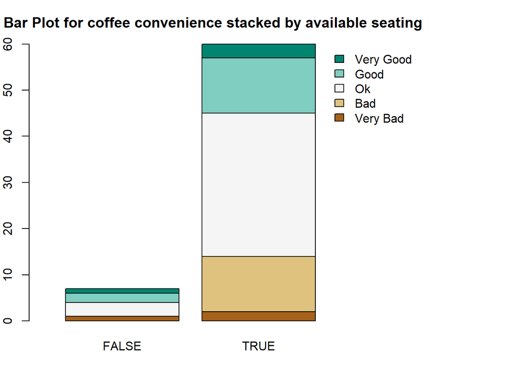

```r
# Stacked barplot
library(RColorBrewer)

par(mar=c(3,2,3,8))
barplot(mytable_5,
        main="Bar Plot for coffee convenience stacked by available seating",
        xlab="Seating", ylab="Frequency",
        xlim=c(0, ncol(mytable_5)+1),
        col= brewer.pal(nrow(mytable_5),  "BrBG"),
        legend.text=rownames(mytable_5),
        args.legend=list(x=ncol(mytable_5) + 1.3, y=max(colSums(mytable_5)), bty = "n"))
```

```r
dev.off()
```

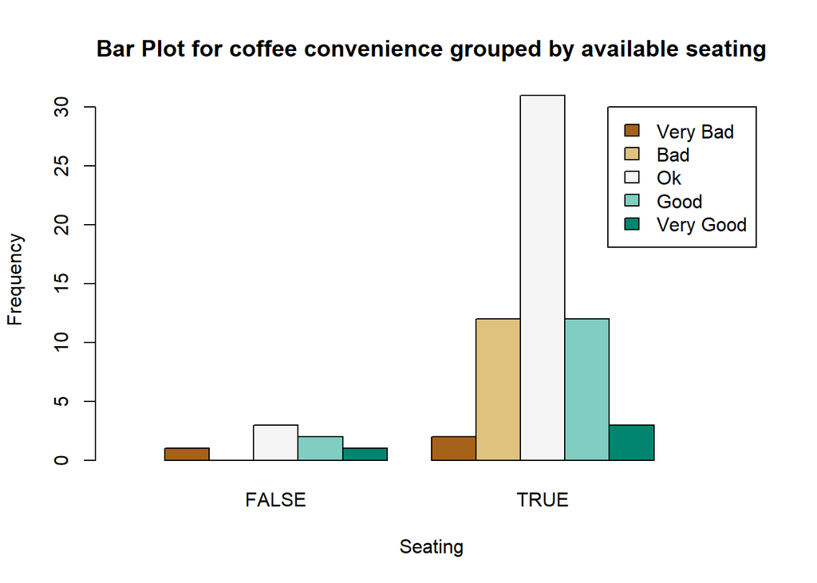

```r
# grouped barplot
barplot(mytable_5,
        main="Bar Plot for coffee convenience grouped by available seating",
        xlab="Seating", ylab="Frequency",
        xlim=c(0, nrow(mytable_5)*2 + 4),
        col= brewer.pal(nrow(mytable_5),  "BrBG"),
        legend.text=rownames(mytable_5), beside=TRUE)
```

### Spinograms

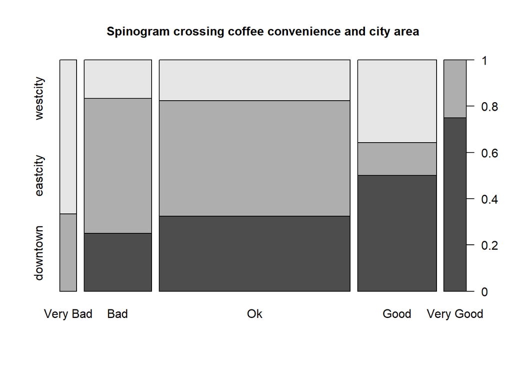

```r
if (!require("vcd")) install.packages("vcd")
library(vcd)

mytable_6 <- table(coffee$convenience_rec, coffee$cityarea)
spine(mytable_6, main="Spinogram crossing coffee convenience and city area")
```

```r
#?spine
```

### Ainda mais gráficos…

```r
library("gplots")
# 1. convert the data as a table
mytable_7 <- xtabs(~ popular + internet, data=coffee)

(DF_table7 <- as.table(as.matrix(mytable_7)))
```

```
##        internet
## popular FALSE TRUE
##   FALSE    27   32
##   TRUE      1    7
```

```r
# 2. Graph
?balloonplot
```

```
## starting httpd help server ...
```

```
##  done
```

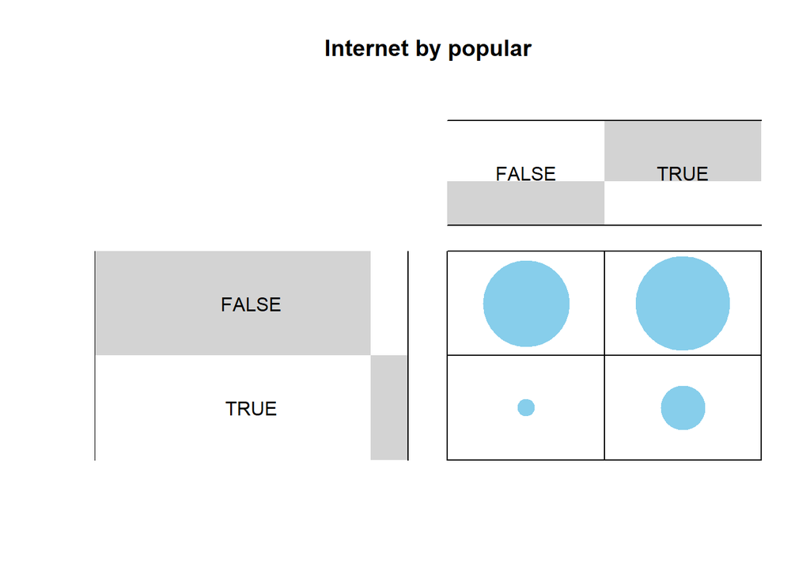

```r
balloonplot(t(DF_table7), main ="Internet by popular", xlab ="", ylab="",
            label = FALSE, show.margins = FALSE)
```

```r
mytable_7
```

```
##        internet
## popular FALSE TRUE
##   FALSE    27   32
##   TRUE      1    7
```

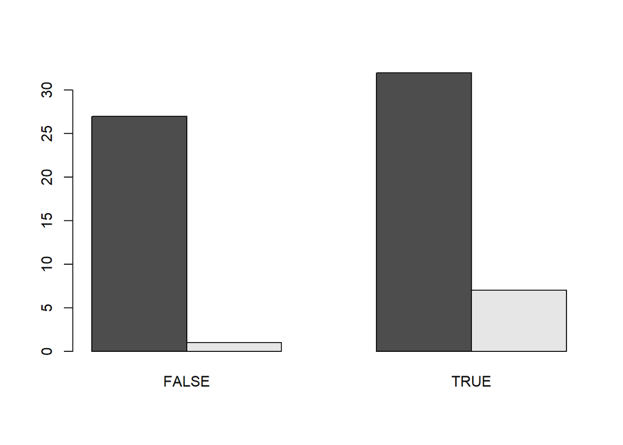

```r
barplot(mytable_7, beside = TRUE)
```

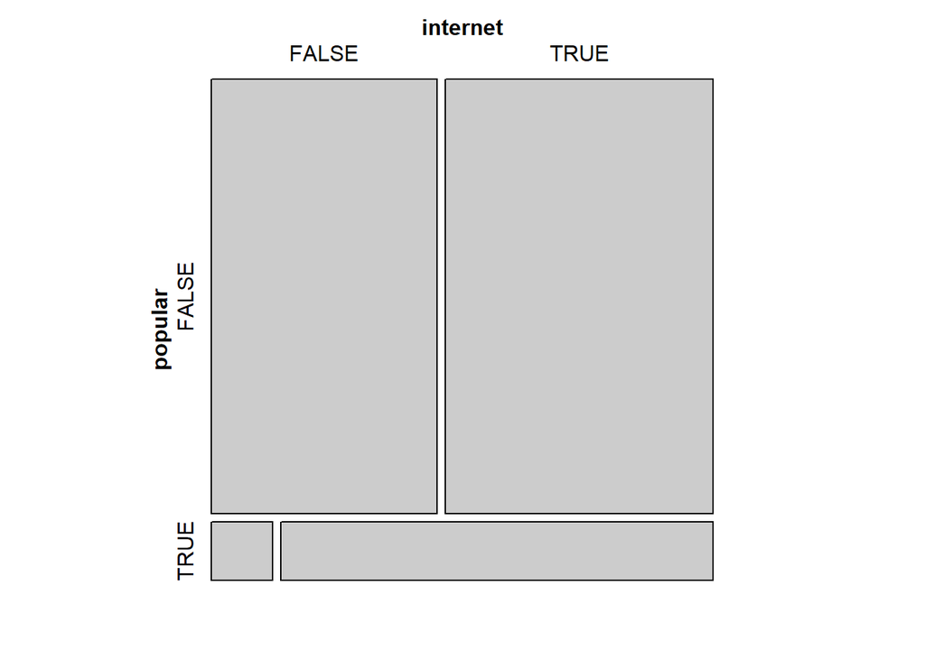

```r
mosaic(mytable_7) # Plots (extended) mosaic displays.
```

O pacote vcd apresenta algumas funções úteis para a vizualização de associação entre variáveis categoriais.

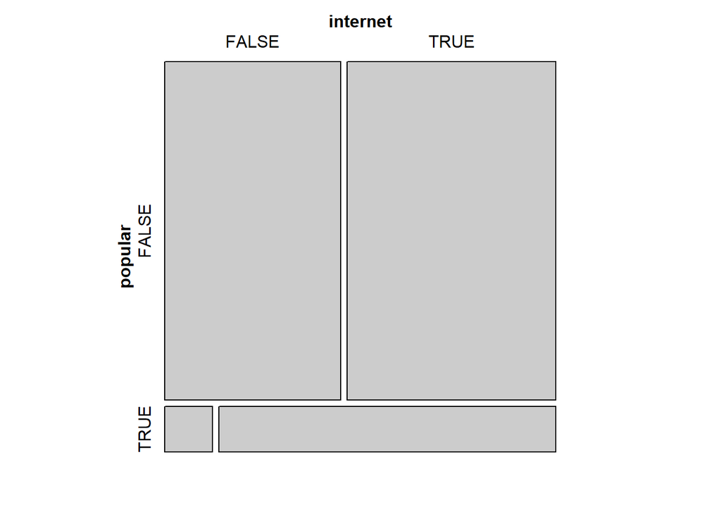

```r
library("vcd")
cotabplot(mytable_7) # cotabplot is a generic function for creating trellis-like coplots (conditional plots) for contingency tables.
```

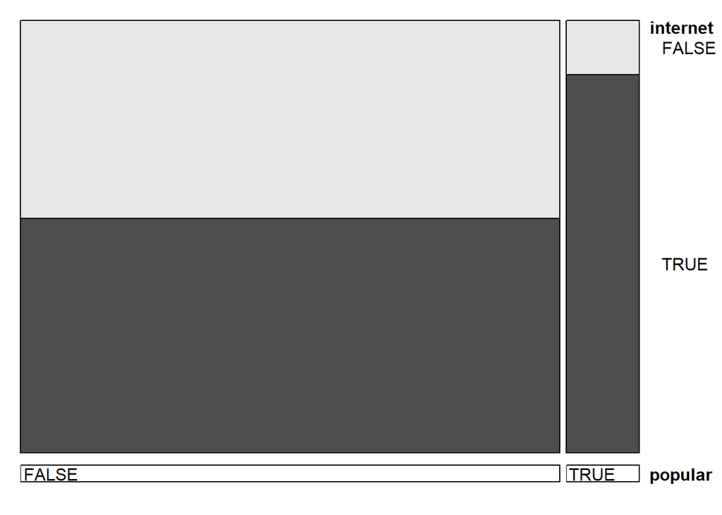

```r
doubledecker(mytable_7, data = coffee) # This function creates a doubledecker plot visualizing a classification rule
```

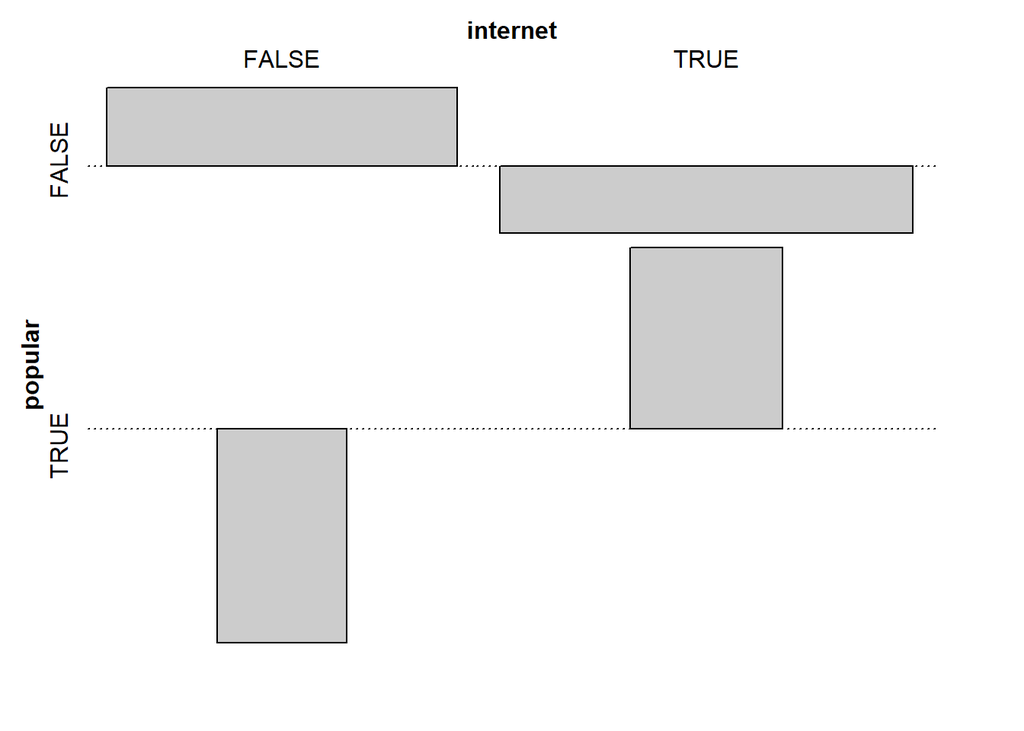

```r
assoc(mytable_7)  # Produce an association plot indicating deviations from a specified independence model in a possibly high-dimensional contingency table.
```

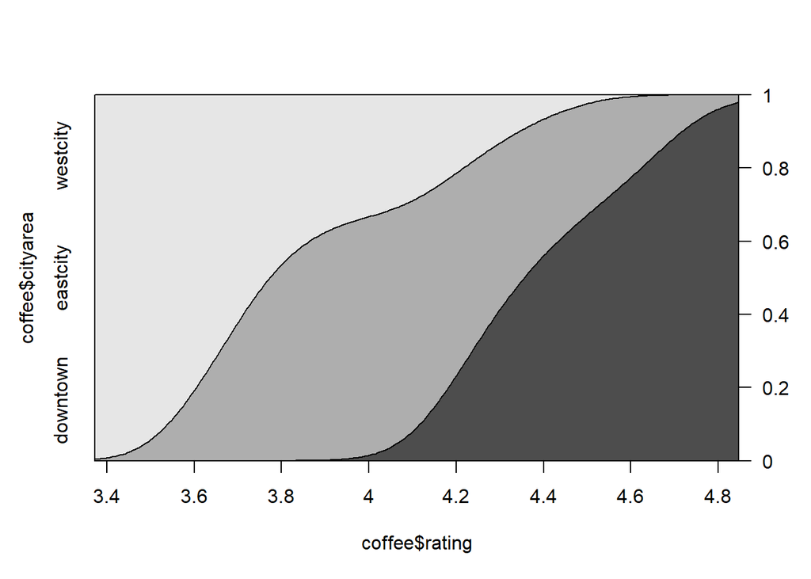

```r
cd_plot(coffee$cityarea~coffee$rating) # Computes and plots conditional densities describing how the distribution of a categorical variable y changes over a numerical variable x.
```

## Testes à independência entre fatores

O R disponibiliza vários testes para avaliar a independência de variáveis categoriais.

### Chi-square test

O Chi-square test permite verificar a independência entre as observações das colunas e linhas de uma tabela de contingências.

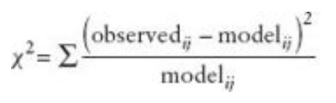

Fig1. chi-square model

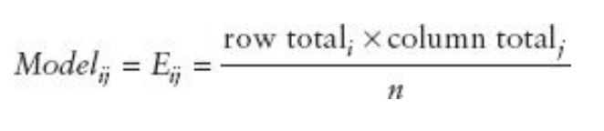

Fig2. Expected frequencies

```r
# step by step
mytable_8 <- xtabs(~ popular + internet, data=coffee)
mat <- matrix(as.numeric(mytable_8), ncol=2)
mytable_8_marg <- addmargins(mytable_8)
mat_marg <- matrix(as.numeric(mytable_8_marg), ncol=3)

# cálculo das frequências esperadas
Eij <- c((mat_marg[1,3]*mat_marg[3,1])/mat_marg[3,3],
         (mat_marg[2,3]*mat_marg[3,1])/mat_marg[3,3],
          (mat_marg[1,3]*mat_marg[3,2])/mat_marg[3,3],
          (mat_marg[2,3]*mat_marg[3,2])/mat_marg[3,3])

Eij <- matrix(Eij, nrow=2)
Eij
```

```
##           [,1]      [,2]
## [1,] 24.656716 34.343284
## [2,]  3.343284  4.656716
```

```r
# Cálculo chi-quadrado
(chi <- sum(((mat - Eij )^2)/Eij))
```

```
## [1] 3.204125
```

```r
# DF
(df <- (nrow(mat)-1)*(ncol(mat)-1))
```

```
## [1] 1
```

```r
# p-value
pchisq(chi, df=df, lower.tail=FALSE)
```

```
## [1] 0.07345278
```

```r
chisq.test(mytable_8, correct=FALSE)
```

```
##
##  Pearson's Chi-squared test
##
## data:  mytable_8
## X-squared = 3.2041, df = 1, p-value = 0.07345
```

```r
chisq.test(mytable_8, correct=TRUE) # Yates’s correction applies to 2 × 2 contingency table to avoid Type I error - subtracts .5 to the differences between observed and estimated model
```

```
##
##  Pearson's Chi-squared test with Yates' continuity correction
##
## data:  mytable_8
## X-squared = 1.9826, df = 1, p-value = 0.1591
```

```r
mytable_9 <- xtabs(~ tea_rec + cityarea, data=coffee)
mytable_9
```

```
##            cityarea
## tea_rec     downtown eastcity westcity
##   Very Bad         0        2        1
##   Bad              8        5        1
##   Ok               7       15       10
##   Good             6        4        3
##   Very Good        3        2        0
```

```r
chisq.test(mytable_9)
```

```
##
##  Pearson's Chi-squared test
##
## data:  mytable_9
## X-squared = 10.799, df = 8, p-value = 0.2134
```

```r
mytable_10 <- xtabs(~ coffee_rec + cityarea, data=coffee)
mytable_10
```

```
##            cityarea
## coffee_rec  downtown eastcity westcity
##   Very Bad         2        2        0
##   Bad              4        6        3
##   Ok               9       13       11
##   Good             6        6        1
##   Very Good        3        1        0
```

```r
chisq.test(mytable_10)
```

```
##
##  Pearson's Chi-squared test
##
## data:  mytable_10
## X-squared = 8.4037, df = 8, p-value = 0.3951
```

```r
#?chisq.test
```

#### Chi-square test: Pressupostos

> Independencia das observações - cada sujeito apenas pode contribuir para uma observação (não utilizar com medidas repetidas);

> As frequências esperadas para cada célula deverão ser maiores que 5, sob pena de se perder poder estatístico para a deteção de efeitos. No caso deste pressuposto ser violado, deve ser utilizado o Fisher’s Exact Test

### Fisher’s Exact Test

O teste de chi-square apresenta uma limitação importante: a sua distribuição amostral é apenas aproximada a uma distribuição de chi-square. Esta aproximação é bastante exata quando lidamos com amostras de dimensão significativa, mas pode não ser suficiente quando lidamos com amostras de menores dimensões. Nestes casos a distribuição da amostra pode ser demasiado distinta da distribuição teórica chi-square. Assim, geralmente considera-se que quando a frequência esperada para cada célula é reduzida (menor que 5) o teste apresenta uma probabilidade significativa de erro do tipo II, o que significa que podemos não rejeitar a H0 (não existem diferenças entre frequências esperadas e observadas) quando na verdade o devemos fazer.

O Fisher’s exact test pode ser utilizado nestas circunstâncias (com amostras de tamanho mais reduzido) para colmatar as limitação do chi-square test. No entanto, este teste apresenta problemas de eficiência com amostras de grandes dimensões, sendo especialmente utilizado em tabelas 2 x 2.

```r
mytable_11 <- xtabs(~ popular + internet, data=coffee)
mytable_11
```

```
##        internet
## popular FALSE TRUE
##   FALSE    27   32
##   TRUE      1    7
```

```r
chisq.test(mytable_11)
```

```
##
##  Pearson's Chi-squared test with Yates' continuity correction
##
## data:  mytable_11
## X-squared = 1.9826, df = 1, p-value = 0.1591
```

```r
fisher.test(mytable_11)
```

```
##
##  Fisher's Exact Test for Count Data
##
## data:  mytable_11
## p-value = 0.1258
## alternative hypothesis: true odds ratio is not equal to 1
## 95 percent confidence interval:
##    0.6736882 275.4794209
## sample estimates:
## odds ratio
##   5.781653
```

```r
mytable_12 <- xtabs(~ tea_rec + cityarea, data=coffee)
mytable_12
```

```
##            cityarea
## tea_rec     downtown eastcity westcity
##   Very Bad         0        2        1
##   Bad              8        5        1
##   Ok               7       15       10
##   Good             6        4        3
##   Very Good        3        2        0
```

```r
chisq.test(mytable_12)
```

```
##
##  Pearson's Chi-squared test
##
## data:  mytable_12
## X-squared = 10.799, df = 8, p-value = 0.2134
```

```r
fisher.test(mytable_12)
```

```
##
##  Fisher's Exact Test for Count Data
##
## data:  mytable_12
## p-value = 0.1846
## alternative hypothesis: two.sided
```

```r
mytable_13 <- xtabs(~ coffee_rec + cityarea, data=coffee)
mytable_13
```

```
##            cityarea
## coffee_rec  downtown eastcity westcity
##   Very Bad         2        2        0
##   Bad              4        6        3
##   Ok               9       13       11
##   Good             6        6        1
##   Very Good        3        1        0
```

```r
chisq.test(mytable_13)
```

```
##
##  Pearson's Chi-squared test
##
## data:  mytable_13
## X-squared = 8.4037, df = 8, p-value = 0.3951
```

```r
fisher.test(mytable_13)
```

```
##
##  Fisher's Exact Test for Count Data
##
## data:  mytable_13
## p-value = 0.4936
## alternative hypothesis: two.sided
```

```r
# ?fisher.test
```

### A função **CrossTable**

A função gmodels::CrossTable permite testar a independência entre variáveis categoriais de uma forma simplificada.

```r
if (!require("gmodels")) install.packages("gmodels")
library(gmodels)
CrossTable(coffee$coffee_rec, coffee$cityarea)
```

```
##
##
##    Cell Contents
## |-------------------------|
## |                       N |
## | Chi-square contribution |
## |           N / Row Total |
## |           N / Col Total |
## |         N / Table Total |
## |-------------------------|
##
##
## Total Observations in Table:  67
##
##
##                   | coffee$cityarea
## coffee$coffee_rec |  downtown |  eastcity |  westcity | Row Total |
## ------------------|-----------|-----------|-----------|-----------|
##          Very Bad |         2 |         2 |         0 |         4 |
##                   |     0.225 |     0.064 |     0.896 |           |
##                   |     0.500 |     0.500 |     0.000 |     0.060 |
##                   |     0.083 |     0.071 |     0.000 |           |
##                   |     0.030 |     0.030 |     0.000 |           |
## ------------------|-----------|-----------|-----------|-----------|
##               Bad |         4 |         6 |         3 |        13 |
##                   |     0.093 |     0.059 |     0.003 |           |
##                   |     0.308 |     0.462 |     0.231 |     0.194 |
##                   |     0.167 |     0.214 |     0.200 |           |
##                   |     0.060 |     0.090 |     0.045 |           |
## ------------------|-----------|-----------|-----------|-----------|
##                Ok |         9 |        13 |        11 |        33 |
##                   |     0.673 |     0.045 |     1.766 |           |
##                   |     0.273 |     0.394 |     0.333 |     0.493 |
##                   |     0.375 |     0.464 |     0.733 |           |
##                   |     0.134 |     0.194 |     0.164 |           |
## ------------------|-----------|-----------|-----------|-----------|
##              Good |         6 |         6 |         1 |        13 |
##                   |     0.387 |     0.059 |     1.254 |           |
##                   |     0.462 |     0.462 |     0.077 |     0.194 |
##                   |     0.250 |     0.214 |     0.067 |           |
##                   |     0.090 |     0.090 |     0.015 |           |
## ------------------|-----------|-----------|-----------|-----------|
##         Very Good |         3 |         1 |         0 |         4 |
##                   |     1.714 |     0.270 |     0.896 |           |
##                   |     0.750 |     0.250 |     0.000 |     0.060 |
##                   |     0.125 |     0.036 |     0.000 |           |
##                   |     0.045 |     0.015 |     0.000 |           |
## ------------------|-----------|-----------|-----------|-----------|
##      Column Total |        24 |        28 |        15 |        67 |
##                   |     0.358 |     0.418 |     0.224 |           |
## ------------------|-----------|-----------|-----------|-----------|
##
##
```

```r
CrossTable(coffee$coffee_rec, coffee$cityarea, fisher = TRUE, chisq = TRUE, expected = TRUE, prop.c = FALSE,
           prop.t = FALSE, prop.chisq = FALSE, sresid = TRUE, format = "SPSS")
```

```
##
##    Cell Contents
## |-------------------------|
## |                   Count |
## |         Expected Values |
## |             Row Percent |
## |            Std Residual |
## |-------------------------|
##
## Total Observations in Table:  67
##
##                   | coffee$cityarea
## coffee$coffee_rec | downtown  | eastcity  | westcity  | Row Total |
## ------------------|-----------|-----------|-----------|-----------|
##          Very Bad |        2  |        2  |        0  |        4  |
##                   |    1.433  |    1.672  |    0.896  |           |
##                   |   50.000% |   50.000% |    0.000% |    5.970% |
##                   |    0.474  |    0.254  |   -0.946  |           |
## ------------------|-----------|-----------|-----------|-----------|
##               Bad |        4  |        6  |        3  |       13  |
##                   |    4.657  |    5.433  |    2.910  |           |
##                   |   30.769% |   46.154% |   23.077% |   19.403% |
##                   |   -0.304  |    0.243  |    0.052  |           |
## ------------------|-----------|-----------|-----------|-----------|
##                Ok |        9  |       13  |       11  |       33  |
##                   |   11.821  |   13.791  |    7.388  |           |
##                   |   27.273% |   39.394% |   33.333% |   49.254% |
##                   |   -0.820  |   -0.213  |    1.329  |           |
## ------------------|-----------|-----------|-----------|-----------|
##              Good |        6  |        6  |        1  |       13  |
##                   |    4.657  |    5.433  |    2.910  |           |
##                   |   46.154% |   46.154% |    7.692% |   19.403% |
##                   |    0.622  |    0.243  |   -1.120  |           |
## ------------------|-----------|-----------|-----------|-----------|
##         Very Good |        3  |        1  |        0  |        4  |
##                   |    1.433  |    1.672  |    0.896  |           |
##                   |   75.000% |   25.000% |    0.000% |    5.970% |
##                   |    1.309  |   -0.519  |   -0.946  |           |
## ------------------|-----------|-----------|-----------|-----------|
##      Column Total |       24  |       28  |       15  |       67  |
## ------------------|-----------|-----------|-----------|-----------|
##
##
## Statistics for All Table Factors
##
##
## Pearson's Chi-squared test
## ------------------------------------------------------------
## Chi^2 =  8.403679     d.f. =  8     p =  0.3950629
##
##
##
## Fisher's Exact Test for Count Data
## ------------------------------------------------------------
## Alternative hypothesis: two.sided
## p =  0.4936418
##
##
##        Minimum expected frequency: 0.8955224
## Cells with Expected Frequency < 5: 10 of 15 (66.66667%)
```

```r
# OR
CrossTable(mytable_12, fisher = TRUE, chisq = TRUE, expected = TRUE, prop.c = FALSE,
           prop.t = FALSE, prop.chisq = FALSE, sresid = TRUE, format = "SPSS")
```

```
##
##    Cell Contents
## |-------------------------|
## |                   Count |
## |         Expected Values |
## |             Row Percent |
## |            Std Residual |
## |-------------------------|
##
## Total Observations in Table:  67
##
##              | cityarea
##      tea_rec | downtown  | eastcity  | westcity  | Row Total |
## -------------|-----------|-----------|-----------|-----------|
##     Very Bad |        0  |        2  |        1  |        3  |
##              |    1.075  |    1.254  |    0.672  |           |
##              |    0.000% |   66.667% |   33.333% |    4.478% |
##              |   -1.037  |    0.666  |    0.401  |           |
## -------------|-----------|-----------|-----------|-----------|
##          Bad |        8  |        5  |        1  |       14  |
##              |    5.015  |    5.851  |    3.134  |           |
##              |   57.143% |   35.714% |    7.143% |   20.896% |
##              |    1.333  |   -0.352  |   -1.206  |           |
## -------------|-----------|-----------|-----------|-----------|
##           Ok |        7  |       15  |       10  |       32  |
##              |   11.463  |   13.373  |    7.164  |           |
##              |   21.875% |   46.875% |   31.250% |   47.761% |
##              |   -1.318  |    0.445  |    1.059  |           |
## -------------|-----------|-----------|-----------|-----------|
##         Good |        6  |        4  |        3  |       13  |
##              |    4.657  |    5.433  |    2.910  |           |
##              |   46.154% |   30.769% |   23.077% |   19.403% |
##              |    0.622  |   -0.615  |    0.052  |           |
## -------------|-----------|-----------|-----------|-----------|
##    Very Good |        3  |        2  |        0  |        5  |
##              |    1.791  |    2.090  |    1.119  |           |
##              |   60.000% |   40.000% |    0.000% |    7.463% |
##              |    0.903  |   -0.062  |   -1.058  |           |
## -------------|-----------|-----------|-----------|-----------|
## Column Total |       24  |       28  |       15  |       67  |
## -------------|-----------|-----------|-----------|-----------|
##
##
## Statistics for All Table Factors
##
##
## Pearson's Chi-squared test
## ------------------------------------------------------------
## Chi^2 =  10.79854     d.f. =  8     p =  0.2133773
##
##
##
## Fisher's Exact Test for Count Data
## ------------------------------------------------------------
## Alternative hypothesis: two.sided
## p =  0.1845731
##
##
##        Minimum expected frequency: 0.6716418
## Cells with Expected Frequency < 5: 9 of 15 (60%)
```

#### Argumentos de **CrossTable**

| FUN_arg | Arg_desc |
| --- | --- |
| digits | number of digits after the decimal point |
| mcnemar | TRUE: produce the results of McNemar’s test for testing differences between two related groups when nominal data have been collected. This test can be applied to compare two related dichotomous variab… |
| prop.c | FALSE: column proportions will not be displayed |
| prop.t | FALSE: total proportions will not be displayed |
| prop.chisq | FALSE: Chi-square proportions will not be displayed |
| resid | TRUE: Produces Pearson residuals |
| sresid | TRUE: Produces standardized residuals |
| asresid | TRUE: Produces adjusted standardized residuals |
| Format | SAS/SPSS: Mimic SAS (default) or SPSS output. To see residuals you need to set the format to SPSS |

### Tamanho do efeito da associação entre variáveis categoriais

Anteriormente, abordamos testes como o chi-square que permitem avaliar a independência de variáveis categoriais. Estes testes fornecem evidência para rejeitar ou não a h0 da independência das variáveis. Após verificação da existência de diferenças, torna-se importante verificar a magnitude dessas diferenças. Esta magnitude pode ser analisada com recurso a distintos indicadores, nomeadamente o phi coefficient (para tabelas 2x2), contingency coefficient o o Cramer’s V. Em geral, valores mais elevados nestes coeficientes são indicativos de associações mais fortes entre as variáveis. Valores próximos de 0 indicam baixa magnitude de associação.

```r
# Measures of association for a two-way table
if (!require("vcd")) install.packages("vcd")
library(vcd)
mytable_13 <- xtabs(~coffee_rec+cityarea, data=coffee)
mytable_13
```

```
##            cityarea
## coffee_rec  downtown eastcity westcity
##   Very Bad         2        2        0
##   Bad              4        6        3
##   Ok               9       13       11
##   Good             6        6        1
##   Very Good        3        1        0
```

```r
assocstats(mytable_13)
```

```
##                      X^2 df P(> X^2)
## Likelihood Ratio 10.0243  8  0.26332
## Pearson           8.4037  8  0.39506
##
## Phi-Coefficient   : NA
## Contingency Coeff.: 0.334
## Cramer's V        : 0.25
```

```r
# ?assocstats
```

# 2. Associação entre variáveis contínuas

Existem dois tipos gerais de correlações:

> Correlações bivariadas;  
> Correlações parciais.

Dentro da categoria dos coeficientes de correlação bivariada existem testes paramétricos (Pearson) e não paramétricos (Spearman e Kendal)

## Breve nota sobre pressupostos de teste paramétricos

Neste ponto iremos abordar alguns dos pressupostos básicos subjacentes a vasto conjunto de testes, habitualmente denominados de testes paramétricos. No entanto, é importante salientar que certos testes tem subjacentes pressupostos adicionais que é importante considerar.

A maioria do procedimentos estatísticos que serão apresentados neste curso são testes paramétricos baseados na distribuição normal.

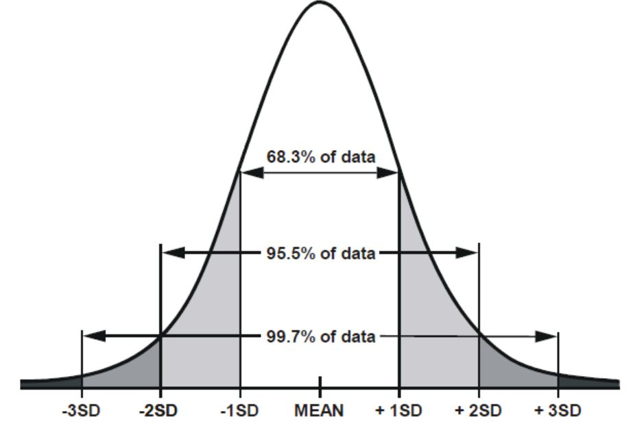

Fig3. normal distribution

Um teste paramétrico tem subjacente 4 pressupostos básicos:

> Os dados apresentam uma distribuição normal  
> As variâncias devem ser homogéneas quando existem multiplos grupos  
> Os dados devem ser intervalares ou contínuos  
> As observações devem ser independentes, isto é os dados dos diferentes participantes deve ser independente.

A não observação destes pressupostos poderá inviabilizar a correta aplicação de um teste paramétrico. Os pressupostos da continuidade dos dados e independência das observações são avaliados facilmente com base no senso comum. Assim, de seguida, focam-se com mais detalhe alguns procedimentos que permitem avaliar em que medida os pressupostos da normalidade e da homogeneidade das variâncias estão cumpridos.

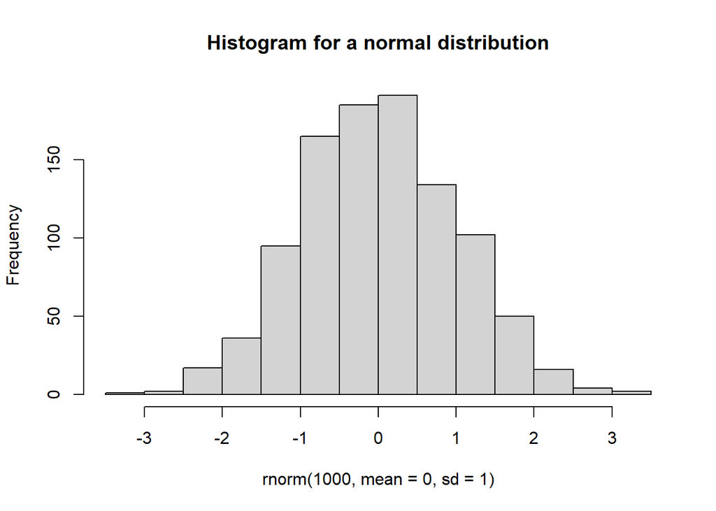

```r
hist(rnorm(1000, mean = 0, sd = 1), main="Histogram for a normal distribution")
```

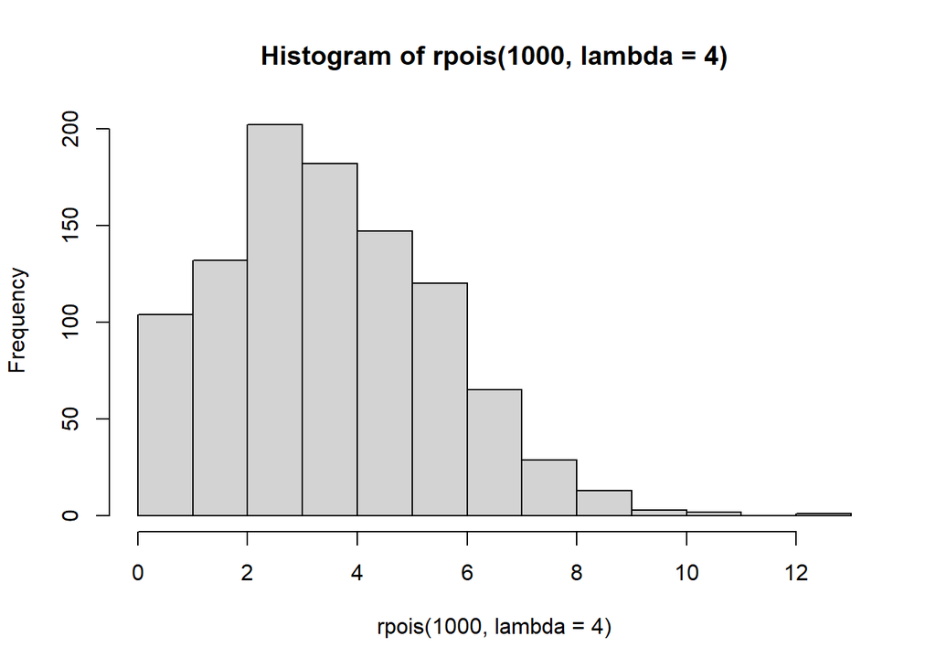

```r
hist(rpois(1000, lambda = 4))
```

### Normalidade

A normalidade de uma distribuição pode ser avaliada de 3 formas distintas e complementares:

> através de representações gráficas  
> através de estatística descritiva  
> através de estatística inferencial

#### Histogramas e Q-Q plots

O Q-Q plot (Quantile-Quantile plot) é um outro gráfico útil na avaliação da normalidade dos dados.

*NOTA: Um quantil é a proporção de casos que podem ser encontrados abaixo de um determinado valor*

O Q-Q plot permite comparar os quartis da distribuição observada com os quartis de uma distribuição normal. Se os dados observados seguirem uma observação normal, os seus valores irão ser semelhantes aos valores de uma distribuição normal, situando-se sobre a linha diagonal do gráfico.

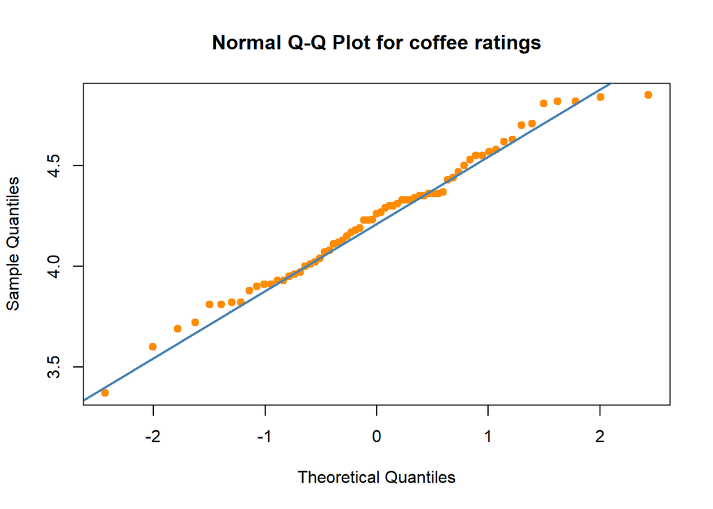

```r
# Normal Q-Q Plot
qqnorm(coffee$rating, main = "Normal Q-Q Plot for coffee ratings",
       col="darkorange", pch=19)
qqline(coffee$rating, col = "steelblue", lwd = 2)
```

```r
?points
?qqnorm
```

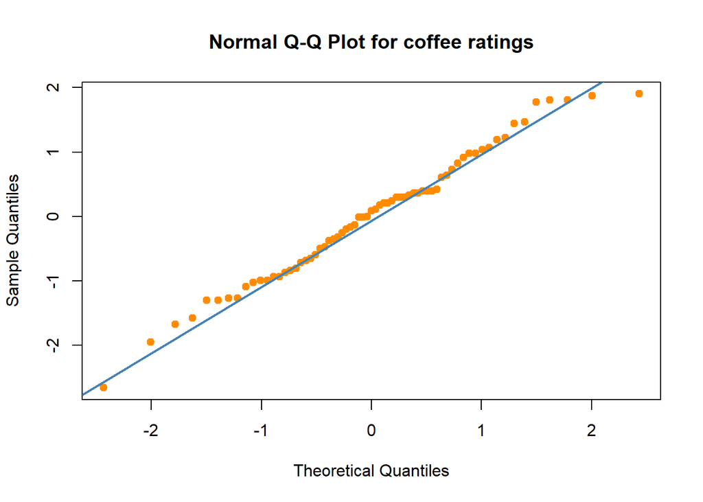

```r
qqnorm(scale(coffee$rating), main = "Normal Q-Q Plot for coffee ratings",
       col="darkorange", pch=19)
qqline(scale(coffee$rating), col = "steelblue", lwd = 2)
```

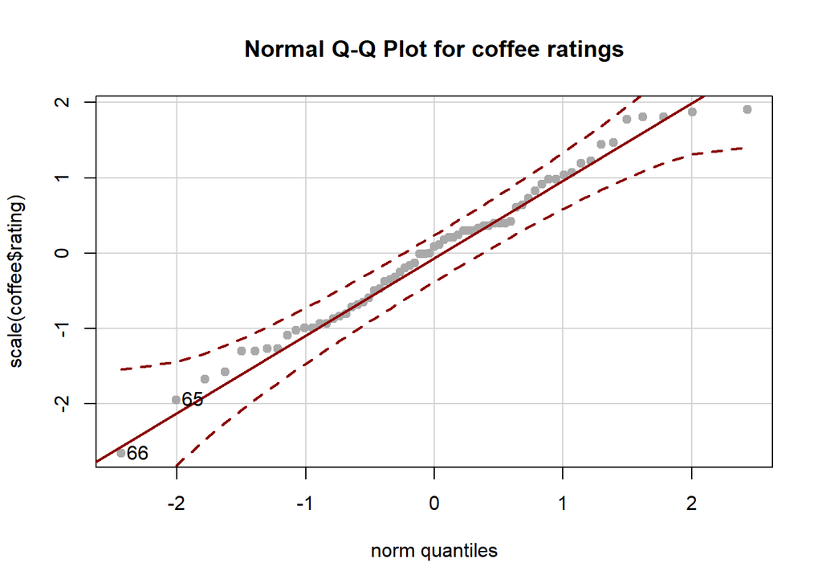

```
## [1] 66 65
```

```r
# Normal Q-Q Plot using car::qqPlot
if (!require("car")) install.packages("car")
library(car)

qqPlot(scale(coffee$rating),
       main = "Normal Q-Q Plot for coffee ratings", col="darkgrey", pch=19, col.lines="darkred")
```

```r
# ?qqPlot
```

#### Assimetria e curtose

```r
skew <- function(x){
  sum((x-mean(x))^3/sd(x)^3)/length(x)
}
skew(coffee$rating)
```

```
## [1] -0.0736431
```

```r
kurt <- function(x){
  sum((x-mean(x))^4/sd(x)^4)/length(x) - 3
}
kurt(coffee$rating)
```

```
## [1] -0.4041726
```

```r
library(psych)
psych::describe(coffee$rating)
```

```
##    vars  n mean   sd median trimmed  mad  min  max range  skew kurtosis   se
## X1    1 67 4.23 0.32   4.26    4.23 0.36 3.37 4.85  1.48 -0.07     -0.4 0.04
```

#### Shapiro–Wilk test

```r
shapiro.test(coffee$rating)
```

```
##
##  Shapiro-Wilk normality test
##
## data:  coffee$rating
## W = 0.98569, p-value = 0.6376
```

O teste Shapiro-Wilk compara os valores de uma distribuição observada com os valores de uma observação normal com a mesma média e desvio padrão. O h0 do teste Shapiro-Wilk é de que distribuição da amostra é proveniente de uma distribuição normal. Assim, se resultado do teste é não significativo (p > .05) indica que a distribuição não é significativamente diferente de uma distribuição normal.

*NOTA: Uma das limitações do teste Shapiro-Wilk é a forte propensão para erro do tipo I em amostras de maiores dimensões. Isto é, há uma grande probabilidade de rejeitar a h0 em amostras grandes, levando a assumir que a mostra tem uma distribuição significativamente diferente da distribuição normal, quando não verdade o desvio face à normalidade poderá ser reduzido.*

```r
library(pastecs)
stat.desc(coffee$rating, basic=FALSE, desc=TRUE, norm=TRUE)
```

```
##       median         mean      SE.mean CI.mean.0.95          var      std.dev
##   4.26000000   4.23242746   0.03966051   0.07918477   0.10538806   0.32463528
##     coef.var     skewness     skew.2SE     kurtosis     kurt.2SE   normtest.W
##   0.07670191  -0.07364310  -0.12574108  -0.40417260  -0.34963254   0.98568861
##   normtest.p
##   0.63760905
```

```r
# ?stat.desc
```

### Homegeneidade das variâncias

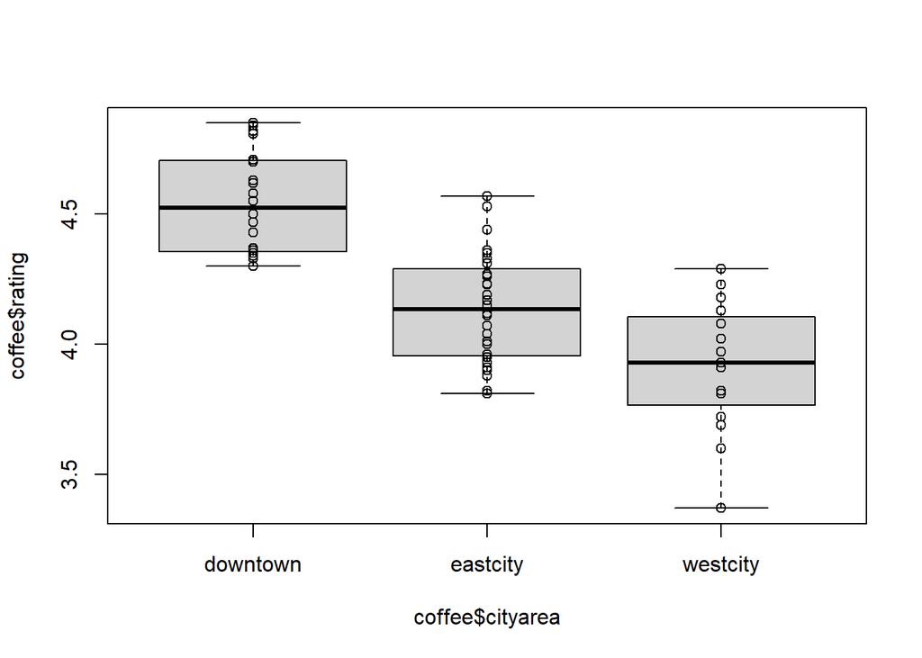

```r
plot(coffee$rating ~ coffee$cityarea)
points(coffee$rating ~ coffee$cityarea)
```

O pressuposto da homogeneidade das variâncias significa que a variância de uma determinada variável não deve ser diferente em distintos níveis de uma outra variável, mantendo-se estável nos diferentes níveis.

O Levene’s test avalia este pressuposto, testando a h0 de que as variâncias nos diferentes grupos são iguais. Assim perante valores de p ≤ .05 indicam que a h0 pode ser rejeitada, concluindo-se que as variâncias são significativamente diferentes entre os diferentes grupos. Resultados não significativos no Levene’s test indicam que as variâncias não são significativamente diferentes, podendo-se assumir a homogeneidade das variáveis.

```r
library(car)
# leveneTest(outcome variable, group, center = median/mean)
leveneTest(coffee$rating, coffee$cityarea)
```

```
## Levene's Test for Homogeneity of Variance (center = median)
##       Df F value Pr(>F)
## group  2  0.3369 0.7153
##       64
```

## Correlações Pearson, Spearman e Kendall

### As funções **cor()** e **cor.test()**

| Argument | Description |
| --- | --- |
| x | numeric variable or dataframe |
| y | numeric variable (NULL if x is a matrix or dataframe) |
| use | string: all.obs (the presence of missing observations will produce an error NA); everything (NA whenever a observations is NA); complete.obs (listwise delection); pairwise.complete.obs (pairwise delec… |
| method | string: pearson (default); spearman; kendall |

```r
names(coffee)
```

```
##  [1] "coffee_shop_name" "cityarea"         "num_reviews"      "popular"
##  [5] "rating"           "ratingMorning"    "ratingLunch"      "ratingAfternoon"
##  [9] "ratingDinner"     "coffee"           "coffee_rec"       "tea"
## [13] "tea_rec"          "food"             "food_rec"         "alcohol"
## [17] "alcohol_rec"      "vibe"             "vibe_rec"         "service"
## [21] "service_rec"      "price"            "price_rec"        "convenience"
## [25] "convenience_rec"  "internet"         "seating"
```

```r
coffee_num <- coffee[c(3,5,10,12,14,16,18,20,22)]
sapply(coffee_num, class)
```

```
## num_reviews      rating      coffee         tea        food     alcohol
##   "numeric"   "numeric"   "numeric"   "numeric"   "numeric"   "numeric"
##        vibe     service       price
##   "numeric"   "numeric"   "numeric"
```

```r
cov(coffee_num) # variances and covariance
```

```
##               num_reviews       rating        coffee           tea
## num_reviews 3923.66169154 -8.309786984 -1.4673236229  0.2645732817
## rating        -8.30978698  0.105388063  0.0249938935  0.0013142326
## coffee        -1.46732362  0.024993893  0.0452973600 -0.0002005280
## tea            0.26457328  0.001314233 -0.0002005280  0.0055205011
## food           0.63781242 -0.011246465 -0.0214883838 -0.0012646458
## alcohol        0.22719302 -0.002669422 -0.0018758264 -0.0006718313
## vibe           4.29361761  0.014436317  0.0070784206  0.0004032603
## service       -0.05774293  0.012582002  0.0022832874  0.0005551421
## price         -0.86358293  0.002051376  0.0009935951 -0.0004167345
##                      food       alcohol          vibe       service
## num_reviews  0.6378124248  0.2271930192  4.2936176124 -0.0577429303
## rating      -0.0112464654 -0.0026694222  0.0144363173  0.0125820021
## coffee      -0.0214883838 -0.0018758264  0.0070784206  0.0022832874
## tea         -0.0012646458 -0.0006718313  0.0004032603  0.0005551421
## food         0.0588616169 -0.0003227266  0.0094388893  0.0001111109
## alcohol     -0.0003227266  0.0079784442 -0.0018780988  0.0017669419
## vibe         0.0094388893 -0.0018780988  0.0470784208 -0.0003924703
## service      0.0001111109  0.0017669419 -0.0003924703  0.0173910928
## price       -0.0003939382 -0.0001411146 -0.0038253437  0.0003544074
##                     price
## num_reviews -0.8635829257
## rating       0.0020513763
## coffee       0.0009935951
## tea         -0.0004167345
## food        -0.0003939382
## alcohol     -0.0001411146
## vibe        -0.0038253437
## service      0.0003544074
## price        0.0034004839
```

```r
cor(coffee_num) # Person correlation
```

```
##             num_reviews      rating      coffee         tea         food
## num_reviews  1.00000000 -0.40864708 -0.11006359  0.05684745  0.041969240
## rating      -0.40864708  1.00000000  0.36174435  0.05448629 -0.142792121
## coffee      -0.11006359  0.36174435  1.00000000 -0.01268088 -0.416151259
## tea          0.05684745  0.05448629 -0.01268088  1.00000000 -0.070155796
## food         0.04196924 -0.14279212 -0.41615126 -0.07015580  1.000000000
## alcohol      0.04060599 -0.09205819 -0.09867272 -0.10123062 -0.014892223
## vibe         0.31591238  0.20495087  0.15328123  0.02501412  0.179305601
## service     -0.00699020  0.29389392  0.08135059  0.05665673  0.003472779
## price       -0.23642201  0.10836256  0.08005761 -0.09618333 -0.027844644
##                 alcohol        vibe      service       price
## num_reviews  0.04060599  0.31591238 -0.006990200 -0.23642201
## rating      -0.09205819  0.20495087  0.293893922  0.10836256
## coffee      -0.09867272  0.15328123  0.081350589  0.08005761
## tea         -0.10123062  0.02501412  0.056656729 -0.09618333
## food        -0.01489222  0.17930560  0.003472779 -0.02784464
## alcohol      1.00000000 -0.09690549  0.150002928 -0.02709209
## vibe        -0.09690549  1.00000000 -0.013716155 -0.30233551
## service      0.15000293 -0.01371616  1.000000000  0.04608599
## price       -0.02709209 -0.30233551  0.046085991  1.00000000
```

```r
cor(coffee_num, method="spearman") # Spearman correlation
```

```
##             num_reviews       rating      coffee          tea          food
## num_reviews  1.00000000 -0.495708572 -0.19556925  0.066537652  1.196504e-01
## rating      -0.49570857  1.000000000  0.39974445 -0.007495191 -1.416361e-01
## coffee      -0.19556925  0.399744449  1.00000000  0.119776397 -4.334112e-01
## tea          0.06653765 -0.007495191  0.11977640  1.000000000 -1.524133e-01
## food         0.11965036 -0.141636145 -0.43341125 -0.152413288  1.000000e+00
## alcohol      0.28361254 -0.278810235 -0.11576176 -0.064434442 -4.318071e-02
## vibe         0.27361544  0.239450417  0.17834644  0.029458855  1.536631e-01
## service     -0.01807185  0.309057575  0.11935304  0.078019398 -4.996003e-05
## price       -0.22244976  0.073653843  0.03130593 -0.087382157 -1.328837e-01
##                  alcohol        vibe       service        price
## num_reviews  0.283612536  0.27361544 -1.807185e-02 -0.222449762
## rating      -0.278810235  0.23945042  3.090576e-01  0.073653843
## coffee      -0.115761755  0.17834644  1.193530e-01  0.031305935
## tea         -0.064434442  0.02945886  7.801940e-02 -0.087382157
## food        -0.043180714  0.15366310 -4.996003e-05 -0.132883709
## alcohol      1.000000000  0.04376785 -9.566610e-04 -0.002180954
## vibe         0.043767847  1.00000000  1.873987e-02 -0.188962644
## service     -0.000956661  0.01873987  1.000000e+00  0.046407167
## price       -0.002180954 -0.18896264  4.640717e-02  1.000000000
```

```r
cor(coffee_num, method="kendall") # Kendall correlation
```

```
##             num_reviews        rating      coffee           tea         food
## num_reviews  1.00000000 -0.3773272095 -0.14079483  0.0548175265  0.094995473
## rating      -0.37732721  1.0000000000  0.27468191 -0.0004790855 -0.093865886
## coffee      -0.14079483  0.2746819092  1.00000000  0.1009764769 -0.304228455
## tea          0.05481753 -0.0004790855  0.10097648  1.0000000000 -0.112241943
## food         0.09499547 -0.0938658858 -0.30422846 -0.1122419431  1.000000000
## alcohol      0.23262592 -0.1996578977 -0.09366019 -0.0439516045 -0.014729523
## vibe         0.21170579  0.1579410801  0.10368579  0.0172435729  0.104875377
## service     -0.01270120  0.2084552365  0.08663686  0.0516875644  0.002308411
## price       -0.17751301  0.0534691784  0.01977133 -0.0641486241 -0.097152088
##                  alcohol        vibe      service        price
## num_reviews  0.232625918  0.21170579 -0.012701198 -0.177513015
## rating      -0.199657898  0.15794108  0.208455237  0.053469178
## coffee      -0.093660192  0.10368579  0.086636865  0.019771329
## tea         -0.043951605  0.01724357  0.051687564 -0.064148624
## food        -0.014729523  0.10487538  0.002308411 -0.097152088
## alcohol      1.000000000  0.04260607  0.003282307  0.006146988
## vibe         0.042606071  1.00000000  0.017527716 -0.140679777
## service      0.003282307  0.01752772  1.000000000  0.034050261
## price        0.006146988 -0.14067978  0.034050261  1.000000000
```

```r
names(coffee_num)
```

```
## [1] "num_reviews" "rating"      "coffee"      "tea"         "food"
## [6] "alcohol"     "vibe"        "service"     "price"
```

```r
coffee_num1 <- coffee_num [1:2]
cor(coffee_num, coffee_num1)
```

```
##             num_reviews      rating
## num_reviews  1.00000000 -0.40864708
## rating      -0.40864708  1.00000000
## coffee      -0.11006359  0.36174435
## tea          0.05684745  0.05448629
## food         0.04196924 -0.14279212
## alcohol      0.04060599 -0.09205819
## vibe         0.31591238  0.20495087
## service     -0.00699020  0.29389392
## price       -0.23642201  0.10836256
```

```r
cor.test(coffee$rating, coffee$num_reviews) # correlation with significance test
```

```
##
##  Pearson's product-moment correlation
##
## data:  x and y
## t = -3.6098, df = 65, p-value = 0.0005966
## alternative hypothesis: true correlation is not equal to 0
## 95 percent confidence interval:
##  -0.5908569 -0.1867721
## sample estimates:
##        cor
## -0.4086471
```

```r
cor.test(coffee$rating, coffee$num_reviews, method="kendall")
```

```
##
##  Kendall's rank correlation tau
##
## data:  x and y
## z = -4.0707, p-value = 4.688e-05
## alternative hypothesis: true tau is not equal to 0
## sample estimates:
##        tau
## -0.3773272
```

```r
# ?cor
# ?cor.test
```

### As funções psych::corr.test e Hmisc:rcorr

```r
library(psych)
corr.test(coffee_num)
```

```
## Call:corr.test(x = coffee_num)
## Correlation matrix
##             num_reviews rating coffee   tea  food alcohol  vibe service price
## num_reviews        1.00  -0.41  -0.11  0.06  0.04    0.04  0.32   -0.01 -0.24
## rating            -0.41   1.00   0.36  0.05 -0.14   -0.09  0.20    0.29  0.11
## coffee            -0.11   0.36   1.00 -0.01 -0.42   -0.10  0.15    0.08  0.08
## tea                0.06   0.05  -0.01  1.00 -0.07   -0.10  0.03    0.06 -0.10
## food               0.04  -0.14  -0.42 -0.07  1.00   -0.01  0.18    0.00 -0.03
## alcohol            0.04  -0.09  -0.10 -0.10 -0.01    1.00 -0.10    0.15 -0.03
## vibe               0.32   0.20   0.15  0.03  0.18   -0.10  1.00   -0.01 -0.30
## service           -0.01   0.29   0.08  0.06  0.00    0.15 -0.01    1.00  0.05
## price             -0.24   0.11   0.08 -0.10 -0.03   -0.03 -0.30    0.05  1.00
## Sample Size
## [1] 67
## Probability values (Entries above the diagonal are adjusted for multiple tests.)
##             num_reviews rating coffee  tea food alcohol vibe service price
## num_reviews        0.00   0.02   1.00 1.00 1.00    1.00 0.30    1.00  1.00
## rating             0.00   0.00   0.09 1.00 1.00    1.00 1.00    0.49  1.00
## coffee             0.38   0.00   0.00 1.00 0.02    1.00 1.00    1.00  1.00
## tea                0.65   0.66   0.92 0.00 1.00    1.00 1.00    1.00  1.00
## food               0.74   0.25   0.00 0.57 0.00    1.00 1.00    1.00  1.00
## alcohol            0.74   0.46   0.43 0.42 0.90    0.00 1.00    1.00  1.00
## vibe               0.01   0.10   0.22 0.84 0.15    0.44 0.00    1.00  0.41
## service            0.96   0.02   0.51 0.65 0.98    0.23 0.91    0.00  1.00
## price              0.05   0.38   0.52 0.44 0.82    0.83 0.01    0.71  0.00
##
##  To see confidence intervals of the correlations, print with the short=FALSE option
```

```r
# ?corr.test
```

```r
library(Hmisc)
rcorr(as.matrix(coffee_num))
```

```
##             num_reviews rating coffee   tea  food alcohol  vibe service price
## num_reviews        1.00  -0.41  -0.11  0.06  0.04    0.04  0.32   -0.01 -0.24
## rating            -0.41   1.00   0.36  0.05 -0.14   -0.09  0.20    0.29  0.11
## coffee            -0.11   0.36   1.00 -0.01 -0.42   -0.10  0.15    0.08  0.08
## tea                0.06   0.05  -0.01  1.00 -0.07   -0.10  0.03    0.06 -0.10
## food               0.04  -0.14  -0.42 -0.07  1.00   -0.01  0.18    0.00 -0.03
## alcohol            0.04  -0.09  -0.10 -0.10 -0.01    1.00 -0.10    0.15 -0.03
## vibe               0.32   0.20   0.15  0.03  0.18   -0.10  1.00   -0.01 -0.30
## service           -0.01   0.29   0.08  0.06  0.00    0.15 -0.01    1.00  0.05
## price             -0.24   0.11   0.08 -0.10 -0.03   -0.03 -0.30    0.05  1.00
##
## n= 67
##
##
## P
##             num_reviews rating coffee tea    food   alcohol vibe   service
## num_reviews             0.0006 0.3753 0.6477 0.7360 0.7442  0.0092 0.9552
## rating      0.0006             0.0026 0.6614 0.2490 0.4587  0.0962 0.0158
## coffee      0.3753      0.0026        0.9189 0.0005 0.4270  0.2156 0.5128
## tea         0.6477      0.6614 0.9189        0.5727 0.4150  0.8408 0.6488
## food        0.7360      0.2490 0.0005 0.5727        0.9048  0.1465 0.9777
## alcohol     0.7442      0.4587 0.4270 0.4150 0.9048         0.4353 0.2257
## vibe        0.0092      0.0962 0.2156 0.8408 0.1465 0.4353         0.9123
## service     0.9552      0.0158 0.5128 0.6488 0.9777 0.2257  0.9123
## price       0.0541      0.3827 0.5196 0.4388 0.8230 0.8277  0.0129 0.7111
##             price
## num_reviews 0.0541
## rating      0.3827
## coffee      0.5196
## tea         0.4388
## food        0.8230
## alcohol     0.8277
## vibe        0.0129
## service     0.7111
## price
```

```r
# ?rcorr
```

Formatação de tabelas de correlação

```r
cor_mat <- rcorr(as.matrix(coffee_num))
class(cor_mat)
```

```
## [1] "rcorr"
```

```r
str(cor_mat)
```

```
## List of 3
##  $ r: num [1:9, 1:9] 1 -0.4086 -0.1101 0.0568 0.042 ...
##   ..- attr(*, "dimnames")=List of 2
##   .. ..$ : chr [1:9] "num_reviews" "rating" "coffee" "tea" ...
##   .. ..$ : chr [1:9] "num_reviews" "rating" "coffee" "tea" ...
##  $ n: int [1:9, 1:9] 67 67 67 67 67 67 67 67 67 67 ...
##   ..- attr(*, "dimnames")=List of 2
##   .. ..$ : chr [1:9] "num_reviews" "rating" "coffee" "tea" ...
##   .. ..$ : chr [1:9] "num_reviews" "rating" "coffee" "tea" ...
##  $ P: num [1:9, 1:9] NA 0.000597 0.375266 0.647722 0.735954 ...
##   ..- attr(*, "dimnames")=List of 2
##   .. ..$ : chr [1:9] "num_reviews" "rating" "coffee" "tea" ...
##   .. ..$ : chr [1:9] "num_reviews" "rating" "coffee" "tea" ...
##  - attr(*, "class")= chr "rcorr"
```

```r
names(cor_mat)
```

```
## [1] "r" "n" "P"
```

```r
#defining flattenCorrMatrix function
flattenCorrMatrix <- function(cormat, pmat) {
  ut <- upper.tri(cormat)
  data.frame(
    row = rownames(cormat)[row(cormat)[ut]],
    column = rownames(cormat)[col(cormat)[ut]],
    cor = (cormat)[ut],
    p = (pmat)[ut]
  )
}

# Extract the correlation coefficients
cor_mat$r
```

```
##             num_reviews      rating      coffee         tea         food
## num_reviews  1.00000000 -0.40864708 -0.11006359  0.05684745  0.041969240
## rating      -0.40864708  1.00000000  0.36174435  0.05448629 -0.142792121
## coffee      -0.11006359  0.36174435  1.00000000 -0.01268088 -0.416151259
## tea          0.05684745  0.05448629 -0.01268088  1.00000000 -0.070155796
## food         0.04196924 -0.14279212 -0.41615126 -0.07015580  1.000000000
## alcohol      0.04060599 -0.09205819 -0.09867272 -0.10123062 -0.014892223
## vibe         0.31591238  0.20495087  0.15328123  0.02501412  0.179305601
## service     -0.00699020  0.29389392  0.08135059  0.05665673  0.003472779
## price       -0.23642201  0.10836256  0.08005761 -0.09618333 -0.027844644
##                 alcohol        vibe      service       price
## num_reviews  0.04060599  0.31591238 -0.006990200 -0.23642201
## rating      -0.09205819  0.20495087  0.293893922  0.10836256
## coffee      -0.09867272  0.15328123  0.081350589  0.08005761
## tea         -0.10123062  0.02501412  0.056656729 -0.09618333
## food        -0.01489222  0.17930560  0.003472779 -0.02784464
## alcohol      1.00000000 -0.09690549  0.150002928 -0.02709209
## vibe        -0.09690549  1.00000000 -0.013716155 -0.30233551
## service      0.15000293 -0.01371616  1.000000000  0.04608599
## price       -0.02709209 -0.30233551  0.046085991  1.00000000
```

```r
# Extract p-values
cor_mat$P
```

```
##              num_reviews       rating       coffee       tea         food
## num_reviews           NA 0.0005965525 0.3752657094 0.6477218 0.7359535244
## rating      0.0005965525           NA 0.0026309622 0.6614428 0.2490226066
## coffee      0.3752657094 0.0026309622           NA 0.9188772 0.0004608231
## tea         0.6477217665 0.6614428045 0.9188772018        NA 0.5726595495
## food        0.7359535244 0.2490226066 0.0004608231 0.5726595           NA
## alcohol     0.7442321816 0.4587397788 0.4269551136 0.4150084 0.9047915439
## vibe        0.0092074904 0.0961649979 0.2155740902 0.8407552 0.1465419685
## service     0.9552293632 0.0157817352 0.5128296352 0.6488258 0.9777490510
## price       0.0540816145 0.3827351162 0.5195737296 0.4387676 0.8230122340
##               alcohol       vibe    service      price
## num_reviews 0.7442322 0.00920749 0.95522936 0.05408161
## rating      0.4587398 0.09616500 0.01578174 0.38273512
## coffee      0.4269551 0.21557409 0.51282964 0.51957373
## tea         0.4150084 0.84075517 0.64882580 0.43876757
## food        0.9047915 0.14654197 0.97774905 0.82301223
## alcohol            NA 0.43532208 0.22566953 0.82772134
## vibe        0.4353221         NA 0.91227941 0.01289547
## service     0.2256695 0.91227941         NA 0.71113820
## price       0.8277213 0.01289547 0.71113820         NA
```

```r
cor_mat2 <- flattenCorrMatrix(cor_mat$r, cor_mat$P)
cor_mat2[,c(-1,-2)] <- round(cor_mat2[,c(-1,-2)],3) #to round only the numeric variables
cor_mat2
```

```
##            row  column    cor     p
## 1  num_reviews  rating -0.409 0.001
## 2  num_reviews  coffee -0.110 0.375
## 3       rating  coffee  0.362 0.003
## 4  num_reviews     tea  0.057 0.648
## 5       rating     tea  0.054 0.661
## 6       coffee     tea -0.013 0.919
## 7  num_reviews    food  0.042 0.736
## 8       rating    food -0.143 0.249
## 9       coffee    food -0.416 0.000
## 10         tea    food -0.070 0.573
## 11 num_reviews alcohol  0.041 0.744
## 12      rating alcohol -0.092 0.459
## 13      coffee alcohol -0.099 0.427
## 14         tea alcohol -0.101 0.415
```

[output cut: 22 more lines]

Formatação de tabelas de correlação

```r
cor_mat <-round(cor(coffee_num),2)

# Lower and upper triangular part of a correlation matrix
lower.tri(cor_mat, diag = FALSE)
```

```
##        [,1]  [,2]  [,3]  [,4]  [,5]  [,6]  [,7]  [,8]  [,9]
##  [1,] FALSE FALSE FALSE FALSE FALSE FALSE FALSE FALSE FALSE
##  [2,]  TRUE FALSE FALSE FALSE FALSE FALSE FALSE FALSE FALSE
##  [3,]  TRUE  TRUE FALSE FALSE FALSE FALSE FALSE FALSE FALSE
##  [4,]  TRUE  TRUE  TRUE FALSE FALSE FALSE FALSE FALSE FALSE
##  [5,]  TRUE  TRUE  TRUE  TRUE FALSE FALSE FALSE FALSE FALSE
##  [6,]  TRUE  TRUE  TRUE  TRUE  TRUE FALSE FALSE FALSE FALSE
##  [7,]  TRUE  TRUE  TRUE  TRUE  TRUE  TRUE FALSE FALSE FALSE
##  [8,]  TRUE  TRUE  TRUE  TRUE  TRUE  TRUE  TRUE FALSE FALSE
##  [9,]  TRUE  TRUE  TRUE  TRUE  TRUE  TRUE  TRUE  TRUE FALSE
```

```r
upper.tri(cor_mat, diag = FALSE)
```

```
##        [,1]  [,2]  [,3]  [,4]  [,5]  [,6]  [,7]  [,8]  [,9]
##  [1,] FALSE  TRUE  TRUE  TRUE  TRUE  TRUE  TRUE  TRUE  TRUE
##  [2,] FALSE FALSE  TRUE  TRUE  TRUE  TRUE  TRUE  TRUE  TRUE
##  [3,] FALSE FALSE FALSE  TRUE  TRUE  TRUE  TRUE  TRUE  TRUE
##  [4,] FALSE FALSE FALSE FALSE  TRUE  TRUE  TRUE  TRUE  TRUE
##  [5,] FALSE FALSE FALSE FALSE FALSE  TRUE  TRUE  TRUE  TRUE
##  [6,] FALSE FALSE FALSE FALSE FALSE FALSE  TRUE  TRUE  TRUE
##  [7,] FALSE FALSE FALSE FALSE FALSE FALSE FALSE  TRUE  TRUE
##  [8,] FALSE FALSE FALSE FALSE FALSE FALSE FALSE FALSE  TRUE
##  [9,] FALSE FALSE FALSE FALSE FALSE FALSE FALSE FALSE FALSE
```

```r
upper.tri(cor_mat)
```

```
##        [,1]  [,2]  [,3]  [,4]  [,5]  [,6]  [,7]  [,8]  [,9]
##  [1,] FALSE  TRUE  TRUE  TRUE  TRUE  TRUE  TRUE  TRUE  TRUE
##  [2,] FALSE FALSE  TRUE  TRUE  TRUE  TRUE  TRUE  TRUE  TRUE
##  [3,] FALSE FALSE FALSE  TRUE  TRUE  TRUE  TRUE  TRUE  TRUE
##  [4,] FALSE FALSE FALSE FALSE  TRUE  TRUE  TRUE  TRUE  TRUE
##  [5,] FALSE FALSE FALSE FALSE FALSE  TRUE  TRUE  TRUE  TRUE
##  [6,] FALSE FALSE FALSE FALSE FALSE FALSE  TRUE  TRUE  TRUE
##  [7,] FALSE FALSE FALSE FALSE FALSE FALSE FALSE  TRUE  TRUE
##  [8,] FALSE FALSE FALSE FALSE FALSE FALSE FALSE FALSE  TRUE
##  [9,] FALSE FALSE FALSE FALSE FALSE FALSE FALSE FALSE FALSE
```

```r
# Hide upper triangle
upper <- cor_mat
upper
```

```
##             num_reviews rating coffee   tea  food alcohol  vibe service price
## num_reviews        1.00  -0.41  -0.11  0.06  0.04    0.04  0.32   -0.01 -0.24
## rating            -0.41   1.00   0.36  0.05 -0.14   -0.09  0.20    0.29  0.11
## coffee            -0.11   0.36   1.00 -0.01 -0.42   -0.10  0.15    0.08  0.08
## tea                0.06   0.05  -0.01  1.00 -0.07   -0.10  0.03    0.06 -0.10
## food               0.04  -0.14  -0.42 -0.07  1.00   -0.01  0.18    0.00 -0.03
## alcohol            0.04  -0.09  -0.10 -0.10 -0.01    1.00 -0.10    0.15 -0.03
## vibe               0.32   0.20   0.15  0.03  0.18   -0.10  1.00   -0.01 -0.30
## service           -0.01   0.29   0.08  0.06  0.00    0.15 -0.01    1.00  0.05
## price             -0.24   0.11   0.08 -0.10 -0.03   -0.03 -0.30    0.05  1.00
```

```r
upper[upper.tri(cor_mat)] <- ""
upper
```

```
##             num_reviews rating  coffee  tea     food    alcohol vibe    service
## num_reviews "1"         ""      ""      ""      ""      ""      ""      ""
## rating      "-0.41"     "1"     ""      ""      ""      ""      ""      ""
## coffee      "-0.11"     "0.36"  "1"     ""      ""      ""      ""      ""
## tea         "0.06"      "0.05"  "-0.01" "1"     ""      ""      ""      ""
## food        "0.04"      "-0.14" "-0.42" "-0.07" "1"     ""      ""      ""
## alcohol     "0.04"      "-0.09" "-0.1"  "-0.1"  "-0.01" "1"     ""      ""
## vibe        "0.32"      "0.2"   "0.15"  "0.03"  "0.18"  "-0.1"  "1"     ""
## service     "-0.01"     "0.29"  "0.08"  "0.06"  "0"     "0.15"  "-0.01" "1"
## price       "-0.24"     "0.11"  "0.08"  "-0.1"  "-0.03" "-0.03" "-0.3"  "0.05"
##             price
## num_reviews ""
## rating      ""
## coffee      ""
## tea         ""
## food        ""
## alcohol     ""
## vibe        ""
## service     ""
## price       "1"
```

```r
upper <- as.data.frame(upper)
upper
```

```
##             num_reviews rating coffee   tea  food alcohol  vibe service price
## num_reviews           1
## rating            -0.41      1
## coffee            -0.11   0.36      1
## tea                0.06   0.05  -0.01     1
## food               0.04  -0.14  -0.42 -0.07     1
## alcohol            0.04  -0.09   -0.1  -0.1 -0.01       1
## vibe               0.32    0.2   0.15  0.03  0.18    -0.1     1
## service           -0.01   0.29   0.08  0.06     0    0.15 -0.01       1
## price             -0.24   0.11   0.08  -0.1 -0.03   -0.03  -0.3    0.05     1
```

```r
#Hide lower triangle
lower <- cor_mat
lower
```

```
##             num_reviews rating coffee   tea  food alcohol  vibe service price
## num_reviews        1.00  -0.41  -0.11  0.06  0.04    0.04  0.32   -0.01 -0.24
## rating            -0.41   1.00   0.36  0.05 -0.14   -0.09  0.20    0.29  0.11
## coffee            -0.11   0.36   1.00 -0.01 -0.42   -0.10  0.15    0.08  0.08
## tea                0.06   0.05  -0.01  1.00 -0.07   -0.10  0.03    0.06 -0.10
## food               0.04  -0.14  -0.42 -0.07  1.00   -0.01  0.18    0.00 -0.03
## alcohol            0.04  -0.09  -0.10 -0.10 -0.01    1.00 -0.10    0.15 -0.03
## vibe               0.32   0.20   0.15  0.03  0.18   -0.10  1.00   -0.01 -0.30
## service           -0.01   0.29   0.08  0.06  0.00    0.15 -0.01    1.00  0.05
## price             -0.24   0.11   0.08 -0.10 -0.03   -0.03 -0.30    0.05  1.00
```

```r
lower[lower.tri(cor_mat, diag=TRUE)] <- ""
lower
```

```
##             num_reviews rating  coffee  tea     food    alcohol vibe   service
## num_reviews ""          "-0.41" "-0.11" "0.06"  "0.04"  "0.04"  "0.32" "-0.01"
## rating      ""          ""      "0.36"  "0.05"  "-0.14" "-0.09" "0.2"  "0.29"
## coffee      ""          ""      ""      "-0.01" "-0.42" "-0.1"  "0.15" "0.08"
## tea         ""          ""      ""      ""      "-0.07" "-0.1"  "0.03" "0.06"
## food        ""          ""      ""      ""      ""      "-0.01" "0.18" "0"
## alcohol     ""          ""      ""      ""      ""      ""      "-0.1" "0.15"
## vibe        ""          ""      ""      ""      ""      ""      ""     "-0.01"
## service     ""          ""      ""      ""      ""      ""      ""     ""
## price       ""          ""      ""      ""      ""      ""      ""     ""
##             price
## num_reviews "-0.24"
## rating      "0.11"
## coffee      "0.08"
## tea         "-0.1"
## food        "-0.03"
## alcohol     "-0.03"
## vibe        "-0.3"
## service     "0.05"
## price       ""
```

```r
lower <- as.data.frame(lower)
lower
```

```
##             num_reviews rating coffee   tea  food alcohol vibe service price
## num_reviews              -0.41  -0.11  0.06  0.04    0.04 0.32   -0.01 -0.24
## rating                           0.36  0.05 -0.14   -0.09  0.2    0.29  0.11
## coffee                                -0.01 -0.42    -0.1 0.15    0.08  0.08
## tea                                         -0.07    -0.1 0.03    0.06  -0.1
## food                                                -0.01 0.18       0 -0.03
## alcohol                                                   -0.1    0.15 -0.03
## vibe                                                             -0.01  -0.3
## service                                                                 0.05
## price
```

```r
# x is a matrix containing the data
# method : correlation method. "pearson"" or "spearman"" is supported
# removeTriangle : remove upper or lower triangle
# results :  if "html" or "latex"
# the results will be displayed in html or latex format
corstars <-function(x, method=c("pearson", "spearman"), removeTriangle=c("upper", "lower"),
                    result=c("none", "html", "latex")){
  #Compute correlation matrix
  require(Hmisc)
  x <- as.matrix(x)
  correlation_matrix<-rcorr(x, type=method[1])
  R <- correlation_matrix$r # Matrix of correlation coeficients
  p <- correlation_matrix$P # Matrix of p-value

  ## Define notions for significance levels; spacing is important.
  mystars <- ifelse(p < .0001, "****", ifelse(p < .001, "*** ", ifelse(p < .01, "**  ", ifelse(p < .05, "*   ", "    "))))

  ## trunctuate the correlation matrix to two decimal
  R <- format(round(cbind(rep(-1.11, ncol(x)), R), 2))[,-1]

  ## build a new matrix that includes the correlations with their apropriate stars
  Rnew <- matrix(paste(R, mystars, sep=""), ncol=ncol(x))
  diag(Rnew) <- paste(diag(R), " ", sep="")
  rownames(Rnew) <- colnames(x)
  colnames(Rnew) <- paste(colnames(x), "", sep="")

  ## remove upper triangle of correlation matrix
  if(removeTriangle[1]=="upper"){
    Rnew <- as.matrix(Rnew)
    Rnew[upper.tri(Rnew, diag = TRUE)] <- ""
    Rnew <- as.data.frame(Rnew)
  }

  ## remove lower triangle of correlation matrix
  else if(removeTriangle[1]=="lower"){
    Rnew <- as.matrix(Rnew)
    Rnew[lower.tri(Rnew, diag = TRUE)] <- ""
    Rnew <- as.data.frame(Rnew)
  }

  ## remove last column and return the correlation matrix
  Rnew <- cbind(Rnew[1:length(Rnew)-1])
  if (result[1]=="none") return(Rnew)
  else{
    if(result[1]=="html") print(xtable(Rnew), type="html")
    else print(xtable(Rnew), type="latex")
  }
}
```

|  | num_reviews | rating | coffee | tea | food | alcohol | vibe | service | price |
| --- | --- | --- | --- | --- | --- | --- | --- | --- | --- |
| num_reviews | 1 |  |  |  |  |  |  |  |  |
| rating | -0.41 | 1 |  |  |  |  |  |  |  |
| coffee | -0.11 | 0.36 | 1 |  |  |  |  |  |  |
| tea | 0.06 | 0.05 | -0.01 | 1 |  |  |  |  |  |
| food | 0.04 | -0.14 | -0.42 | -0.07 | 1 |  |  |  |  |
| alcohol | 0.04 | -0.09 | -0.1 | -0.1 | -0.01 | 1 |  |  |  |
| vibe | 0.32 | 0.2 | 0.15 | 0.03 | 0.18 | -0.1 | 1 |  |  |
| service | -0.01 | 0.29 | 0.08 | 0.06 | 0 | 0.15 | -0.01 | 1 |  |
| price | -0.24 | 0.11 | 0.08 | -0.1 | -0.03 | -0.03 | -0.3 | 0.05 | 1 |

|  | num_reviews | rating | coffee | tea | food | alcohol | vibe | service |
| --- | --- | --- | --- | --- | --- | --- | --- | --- |
| num_reviews |  |  |  |  |  |  |  |  |
| rating | -0.41*** |  |  |  |  |  |  |  |
| coffee | -0.11 | 0.36** |  |  |  |  |  |  |
| tea | 0.06 | 0.05 | -0.01 |  |  |  |  |  |
| food | 0.04 | -0.14 | -0.42*** | -0.07 |  |  |  |  |
| alcohol | 0.04 | -0.09 | -0.10 | -0.10 | -0.01 |  |  |  |
| vibe | 0.32** | 0.20 | 0.15 | 0.03 | 0.18 | -0.10 |  |  |
| service | -0.01 | 0.29* | 0.08 | 0.06 | 0.00 | 0.15 | -0.01 |  |
| price | -0.24 | 0.11 | 0.08 | -0.10 | -0.03 | -0.03 | -0.30* | 0.05 |

|  | num_reviews | rating | coffee | tea | food | alcohol | vibe | service |
| --- | --- | --- | --- | --- | --- | --- | --- | --- |
| num_reviews |  |  |  |  |  |  |  |  |
| rating | -0.41*** |  |  |  |  |  |  |  |
| coffee | -0.11 | 0.36** |  |  |  |  |  |  |
| tea | 0.06 | 0.05 | -0.01 |  |  |  |  |  |
| food | 0.04 | -0.14 | -0.42*** | -0.07 |  |  |  |  |
| alcohol | 0.04 | -0.09 | -0.10 | -0.10 | -0.01 |  |  |  |
| vibe | 0.32** | 0.20 | 0.15 | 0.03 | 0.18 | -0.10 |  |  |
| service | -0.01 | 0.29* | 0.08 | 0.06 | 0.00 | 0.15 | -0.01 |  |
| price | -0.24 | 0.11 | 0.08 | -0.10 | -0.03 | -0.03 | -0.30* | 0.05 |

## Visualização da associação entre variáveis contínuas

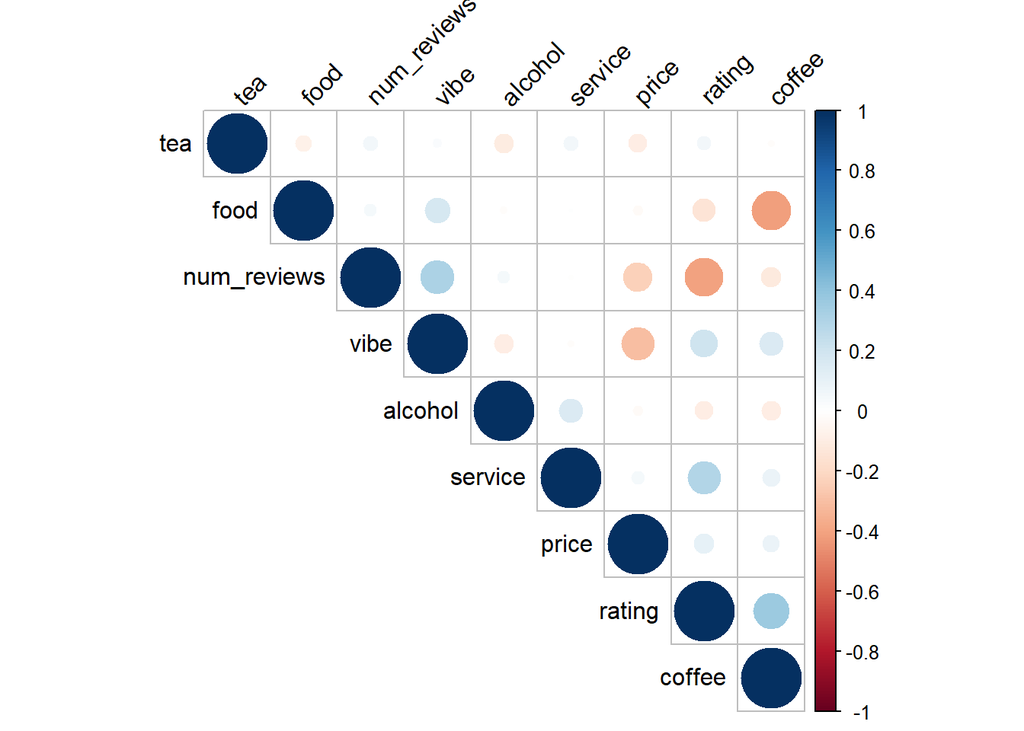

```r
if (!require("corrplot")) install.packages("corrplot")
library(corrplot)
library(Hmisc)

corrplot(cor(coffee_num), type = "upper", order = "hclust",
         tl.col = "black", tl.srt = 45)
```

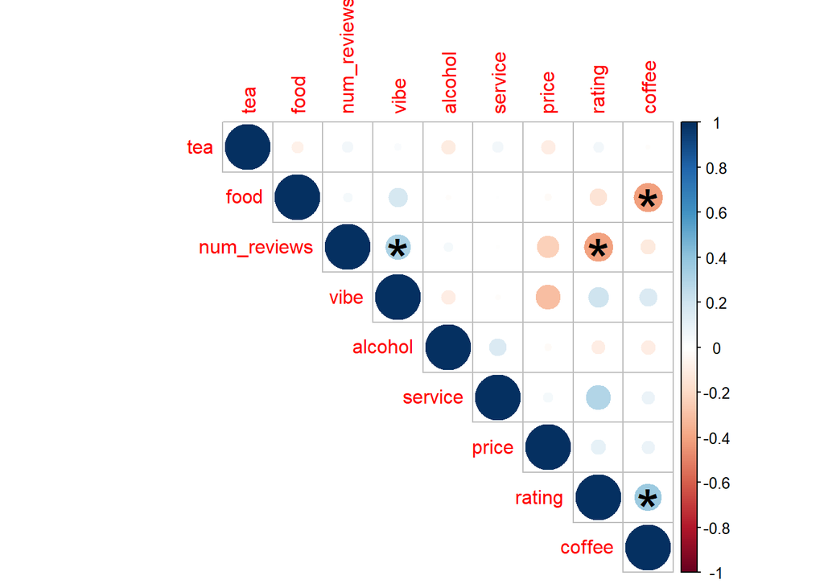

```r
cor_mat <- Hmisc::rcorr(as.matrix(coffee_num))
# Insignificant correlation are crossed
corrplot(cor_mat$r, type="upper", order="hclust",
         p.mat = cor_mat$P, sig.level = 0.01, insig = "label_sig")
```

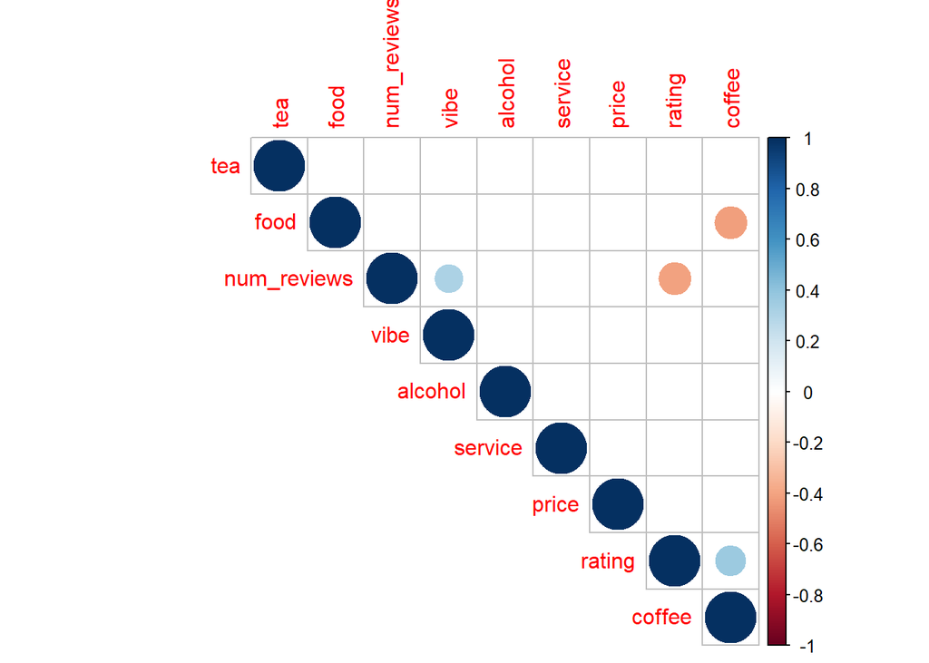

```r
# Insignificant correlations are leaved blank
corrplot(cor_mat$r, type="upper", order="hclust",
         p.mat = cor_mat$P, sig.level = 0.01, insig = "blank")
```

```r
#?corrplot
```

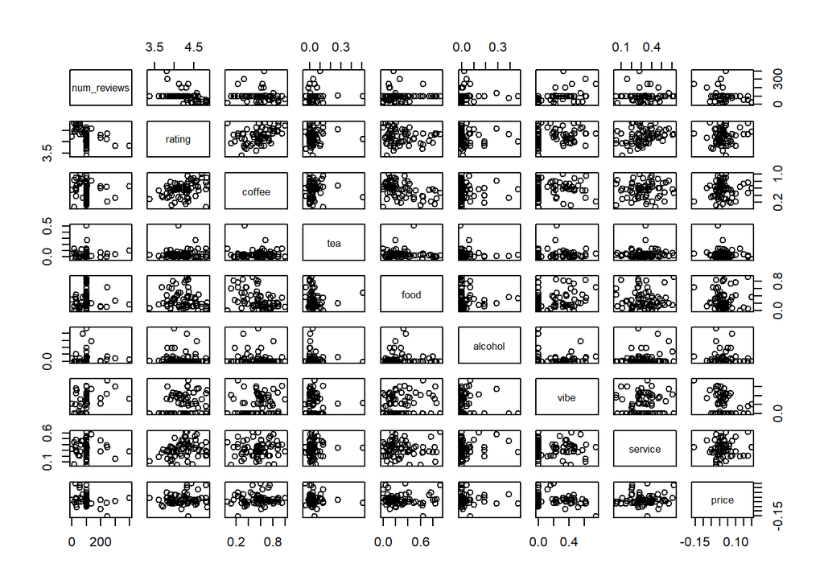

```r
plot(coffee_num)
```

```r
if (!require("PerformanceAnalytics")) install.packages("PerformanceAnalytics")
```

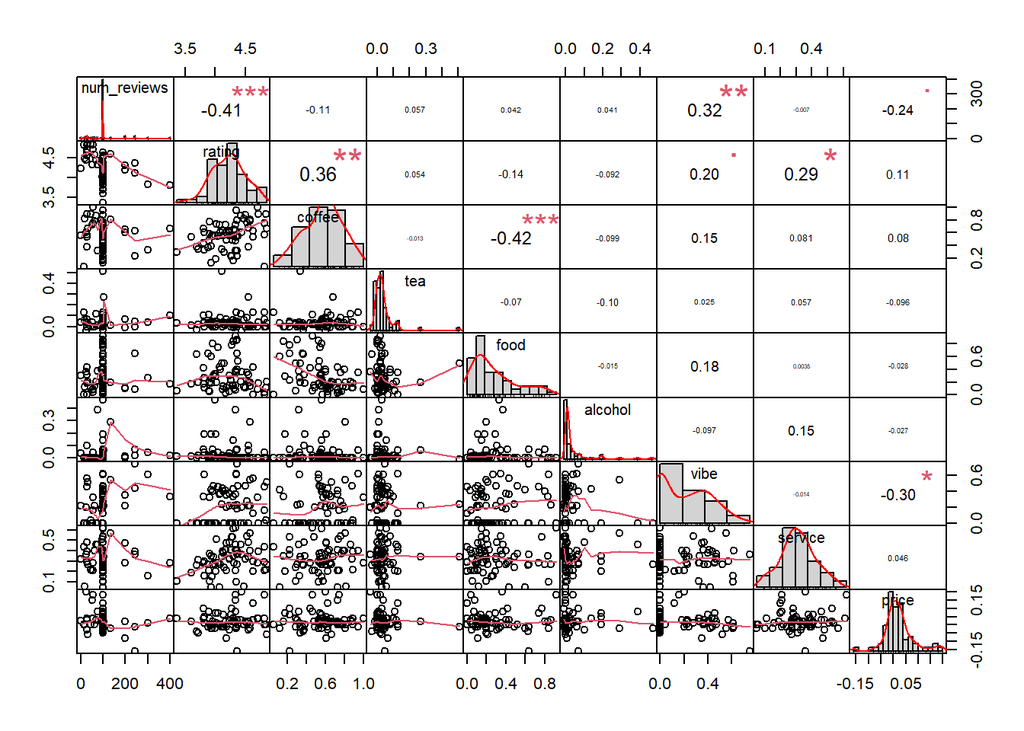

```r
library(PerformanceAnalytics)
chart.Correlation(coffee_num, histogram=TRUE, pch=19)
```

```r
#?chart.Correlation
```

## Correlação parcial

```r
if (!require("ggm")) install.packages("ggm")
library(ggm)
names(coffee_num)
```

```
## [1] "num_reviews" "rating"      "coffee"      "tea"         "food"
## [6] "alcohol"     "vibe"        "service"     "price"
```

```r
cor(coffee_num$rating, coffee_num$coffee)
```

```
## [1] 0.3617444
```

```r
pcor(c(2, 3, 4:9), cov(coffee_num))
```

```
## [1] 0.2485248
```

```r
#?pcor
```

A significância da correlação parcial pode ser avaliada através da função psych::pcor.test.

```r
pcor.test(r, # result of pcor()
          q, # number of variables being controlled
          n) # sample size
```

```r
library(psych)
pcor.test(pcor(c(2, 3, 4:9), cov(coffee_num)), q= 6, n = nrow(coffee_num))
```

```
## $tval
## [1] 1.970787
##
## $df
## [1] 59
##
## $pvalue
## [1] 0.05344546
```

```r
nrow(coffee_num)
```

```
## [1] 67
```

# 3. Comparações de médias

## t-test

O t-test permite comparar dois grupos quando a variável de interesse (outcome) é contínua e com uma distribuição normal.

### t-test para amostras independentes

O t-test para amostras independentes é utilizado para avaliar a hipótese de que as médias de duas populações são iguais (h0), assumindo que os dois grupos são independentes e que os dados são retirados de uma população normal. A função genérica no R para o t test é:

```r
t.test(y ~ x, data) # y é uma variável numérica e x é uma variável dicotómica; data corresponde a uma matriz ou DF.
```

O t-test para amostras independentes é utilizado para avaliar a hipótese de que as médias de duas populações são iguais (h0), assumindo que os dois grupos são independentes e que os dados são retirados de uma população normal. A função genérica no R para o t test é:

Por defeito, e ao contrário da maioria das pacotes estatísticos, esta função assume a heterogeneidade das variâncias, aplicando welsh’s t-test. Este teste é uma adaptação do Student’s t-test, sendo robusto a amostras com diferentes variâncias.  
O argumento var.equal=TRUE pode ser acrescentado à função para aplicar o Student’s t-test, assumindo-se a homogeneidade das variâncias.  
Por defeito a hipótese alternativa é two tailed. Este comportamento também pode ser alterado com o argumento alternative=”less” ou alternative=”greater”

A função anterior pode ser utilizada como vetores numéricos para os outcomes medidos nos dois grupos:

```r
t.test(y1, y2 , data) # Neste caso y1 e y2 são o outcome medidos nos dois grupos
```

```r
names(coffee)
```

```
##  [1] "coffee_shop_name" "cityarea"         "num_reviews"      "popular"
##  [5] "rating"           "ratingMorning"    "ratingLunch"      "ratingAfternoon"
##  [9] "ratingDinner"     "coffee"           "coffee_rec"       "tea"
## [13] "tea_rec"          "food"             "food_rec"         "alcohol"
## [17] "alcohol_rec"      "vibe"             "vibe_rec"         "service"
## [21] "service_rec"      "price"            "price_rec"        "convenience"
## [25] "convenience_rec"  "internet"         "seating"
```

```r
str(coffee)
```

```
## 'data.frame':    67 obs. of  27 variables:
##  $ coffee_shop_name: chr  "Manana Coffee & Juice " "Brian's Brew " "Flitch Coffee " "Third Coast Coffee Roasting Company " ...
##  $ cityarea        : Factor w/ 3 levels "downtown","eastcity",..: 1 1 1 1 1 1 1 1 1 1 ...
##  $ num_reviews     : num  33 45 28 56 16 28 57 30 100 136 ...
##  $ popular         : logi  FALSE FALSE FALSE FALSE FALSE FALSE ...
##  $ rating          : num  4.85 4.84 4.82 4.82 4.81 4.71 4.7 4.63 4.62 4.58 ...
##  $ ratingMorning   : num  5.29 4.8 4.99 4.89 4.43 ...
##  $ ratingLunch     : num  5.04 4.59 4.17 4.39 5.09 ...
##  $ ratingAfternoon : num  5.26 4.52 4.51 4.31 4.5 ...
##  $ ratingDinner    : num  4.38 4.3 5.15 3.95 5.2 ...
##  $ coffee          : num  0.67 0.89 0.57 0.75 0.06 0.89 1 0.53 0.63 0.81 ...
##  $ coffee_rec      : Ord.factor w/ 5 levels "Very Bad"<"Bad"<..: 3 5 3 4 1 5 5 3 3 4 ...
##  $ tea             : num  0.03 0 0.07 0 0.13 0.04 0 0 0.13 0.01 ...
##  $ tea_rec         : Ord.factor w/ 5 levels "Very Bad"<"Bad"<..: 3 2 4 2 5 3 2 2 5 3 ...
##  $ food            : num  0.21 0.11 0 0.04 0 0.18 0.09 0.43 0 0.2 ...
##  $ food_rec        : Ord.factor w/ 5 levels "Very Bad"<"Bad"<..: 3 3 1 2 1 3 2 4 1 3 ...
##  $ alcohol         : num  0 0 0 0.04 0 0 0 0 0 0.29 ...
##  $ alcohol_rec     : Ord.factor w/ 5 levels "Very Bad"<"Bad"<..: 3 3 3 4 3 3 3 3 3 5 ...
##  $ vibe            : num  0.52 0.04 0.46 0.16 0 0 0.32 0.57 0.12 0.55 ...
##  $ vibe_rec        : Ord.factor w/ 5 levels "Very Bad"<"Bad"<..: 4 3 4 3 3 3 3 4 3 4 ...
##  $ service         : num  0.27 0.22 0.29 0.21 0.44 0.39 0.28 0.3 0.2 0.57 ...
##  $ service_rec     : Ord.factor w/ 5 levels "Very Bad"<"Bad"<..: 3 2 3 2 4 3 3 3 2 5 ...
##  $ price           : num  -0.06 0 0.04 0.18 0 0.04 0.04 0.03 0.13 -0.02 ...
##  $ price_rec       : Ord.factor w/ 5 levels "Very Bad"<"Bad"<..: 1 3 4 5 3 4 4 3 4 2 ...
##  $ convenience     : num  0.0375 0.0375 0.0725 0.05 0.1575 ...
##  $ convenience_rec : Ord.factor w/ 5 levels "Very Bad"<"Bad"<..: 3 3 4 3 5 4 2 2 3 4 ...
##  $ internet        : logi  FALSE FALSE FALSE FALSE FALSE FALSE ...
##  $ seating         : logi  TRUE TRUE TRUE FALSE FALSE FALSE ...
```

```r
library(car)
leveneTest(coffee$rating, coffee$popular)
```

```
## Levene's Test for Homogeneity of Variance (center = median)
##       Df F value Pr(>F)
## group  1  0.1669 0.6842
##       65
```

```r
leveneTest(coffee$rating, as.factor(coffee$popular)) # equal variances can be assumed
```

```
## Levene's Test for Homogeneity of Variance (center = median)
##       Df F value Pr(>F)
## group  1  0.1669 0.6842
##       65
```

```r
t.test(rating ~ popular, data=coffee, var.equal=TRUE) # h0 (no differences) is retained
```

```
##
##  Two Sample t-test
##
## data:  rating by popular
## t = 0.14908, df = 65, p-value = 0.8819
## alternative hypothesis: true difference in means is not equal to 0
## 95 percent confidence interval:
##  -0.2277288  0.2644708
## sample estimates:
## mean in group FALSE  mean in group TRUE
##            4.234621            4.216250
```

```r
leveneTest(coffee$rating, as.factor(coffee$internet)) # equal variances can be assumed
```

```
## Levene's Test for Homogeneity of Variance (center = median)
##       Df F value Pr(>F)
## group  1  0.4829 0.4896
##       65
```

```r
t.test(rating ~ internet, data=coffee, var.equal=TRUE) # h0 (no differences) is rejected
```

```
##
##  Two Sample t-test
##
## data:  rating by internet
## t = 2.4814, df = 65, p-value = 0.01568
## alternative hypothesis: true difference in means is not equal to 0
## 95 percent confidence interval:
##  0.0375017 0.3468318
## sample estimates:
## mean in group FALSE  mean in group TRUE
##            4.344286            4.152119
```

### t-test para amostras dependentes

O t-test para amostras dependentes aplica-se quando as observações nos dois grupos estão relacionados. Este teste deve ser aplicado quando as medidas são repetidas (e.g., estudos longitudinais com dois momentos; duas condições experimentais com os mesmos sujeitos no grupo de controlo e experimental). No exemplo seguinte, verificamos diferenças na média dos ratings dos cafés no período da manha (grupo 1) e no período da tarde (grupo 2) - assume-se que as mesma pessoas atribuem os ratings em diferentes momentos do dia. Verifica-se assim a não independências das observações, uma vez que as mesmas pessoas avaliam o mesmo café em momentos diferentes.

```r
names(coffee)
```

```
##  [1] "coffee_shop_name" "cityarea"         "num_reviews"      "popular"
##  [5] "rating"           "ratingMorning"    "ratingLunch"      "ratingAfternoon"
##  [9] "ratingDinner"     "coffee"           "coffee_rec"       "tea"
## [13] "tea_rec"          "food"             "food_rec"         "alcohol"
## [17] "alcohol_rec"      "vibe"             "vibe_rec"         "service"
## [21] "service_rec"      "price"            "price_rec"        "convenience"
## [25] "convenience_rec"  "internet"         "seating"
```

```r
cor.test(coffee$ratingMorning, coffee$ratingAfternoon)
```

```
##
##  Pearson's product-moment correlation
##
## data:  x and y
## t = 4.9331, df = 65, p-value = 5.911e-06
## alternative hypothesis: true correlation is not equal to 0
## 95 percent confidence interval:
##  0.3220993 0.6772296
## sample estimates:
##      cor
## 0.521926
```

```r
library(reshape2)
coffee_rec <- melt(coffee[c(6,8)])
names(coffee_rec) <- c("Morn_After", "rating")
str(coffee_rec)
```

```
## 'data.frame':    134 obs. of  2 variables:
##  $ Morn_After: Factor w/ 2 levels "ratingMorning",..: 1 1 1 1 1 1 1 1 1 1 ...
##  $ rating    : num  5.29 4.8 4.99 4.89 4.43 ...
```

```r
t.test(coffee_rec$rating ~ coffee_rec$Morn_After, paired = TRUE)
```

```
##
##  Paired t-test
##
## data:  coffee_rec$rating by coffee_rec$Morn_After
## t = 0.071529, df = 66, p-value = 0.9432
## alternative hypothesis: true difference in means is not equal to 0
## 95 percent confidence interval:
##  -0.0999019  0.1073260
## sample estimates:
## mean of the differences
##             0.003712062
```

```r
# OR

t.test(coffee$ratingMorning, coffee$ratingAfternoon, paired = TRUE)
```

```
##
##  Paired t-test
##
## data:  coffee$ratingMorning and coffee$ratingAfternoon
## t = 0.071529, df = 66, p-value = 0.9432
## alternative hypothesis: true difference in means is not equal to 0
## 95 percent confidence interval:
##  -0.0999019  0.1073260
## sample estimates:
## mean of the differences
##             0.003712062
```

No exemplo anterior a diferença de médias não é suficiente para a rejeição da h0, de que as médias entre os grupos são iguais.

## Testes não paramétricos

### Wilcoxon rank sum test (ou Mann-Whitney U test) para amostras independentes

```r
names(coffee)
```

```
##  [1] "coffee_shop_name" "cityarea"         "num_reviews"      "popular"
##  [5] "rating"           "ratingMorning"    "ratingLunch"      "ratingAfternoon"
##  [9] "ratingDinner"     "coffee"           "coffee_rec"       "tea"
## [13] "tea_rec"          "food"             "food_rec"         "alcohol"
## [17] "alcohol_rec"      "vibe"             "vibe_rec"         "service"
## [21] "service_rec"      "price"            "price_rec"        "convenience"
## [25] "convenience_rec"  "internet"         "seating"
```

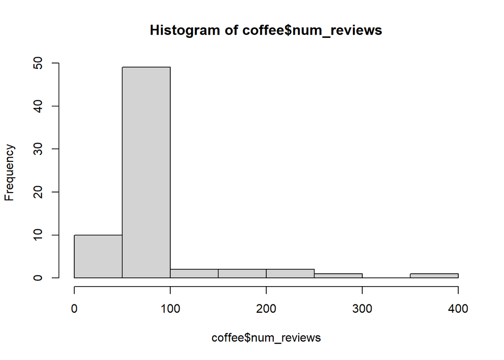

```r
hist(coffee$num_reviews)
```

```r
wilcox.test(coffee$num_reviews ~ coffee$internet)
```

```
##
##  Wilcoxon rank sum test with continuity correction
##
## data:  coffee$num_reviews by coffee$internet
## W = 337, p-value = 0.002538
## alternative hypothesis: true location shift is not equal to 0
```

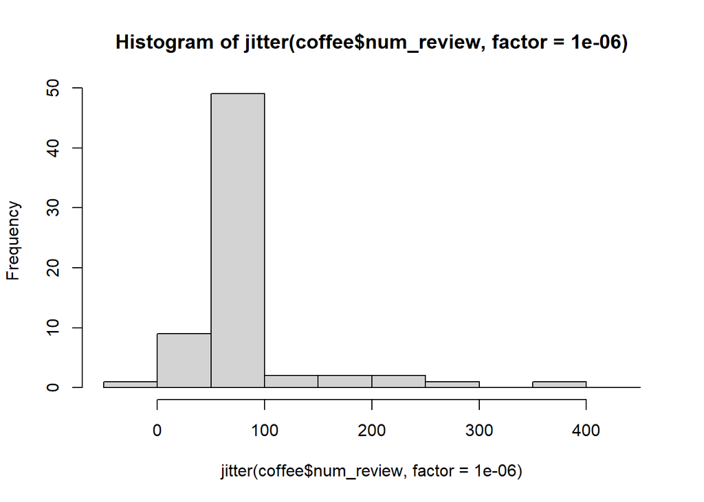

```r
hist(jitter(coffee$num_review, factor = .000001))
```

```r
cor(coffee$num_reviews, jitter(coffee$num_review, factor = .000001))
```

```
## [1] 1
```

```r
wilcox.test(jitter(coffee$num_review, factor = .000001) ~ coffee$internet)
```

```
##
##  Wilcoxon rank sum exact test
##
## data:  jitter(coffee$num_review, factor = 1e-06) by coffee$internet
## W = 395, p-value = 0.05533
## alternative hypothesis: true location shift is not equal to 0
```

```r
library(psych)
psych::describe(coffee$num_reviews) # wilcox test may incorrectly reject the null hypothesis (Type I error) when the sampled is excessively skewed
```

```
##    vars  n   mean    sd median trimmed mad min max range skew kurtosis   se
## X1    1 67 100.63 62.64    100   91.65   0   0 400   400 2.28      7.7 7.65
```

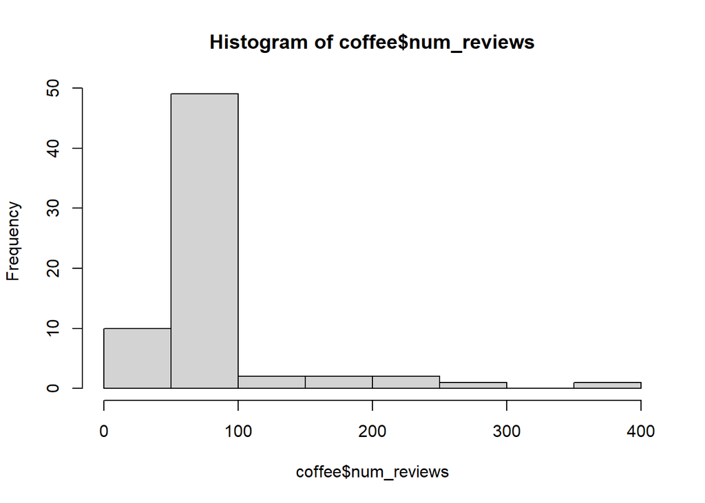

```r
hist(coffee$num_reviews)
```

```r
psych::describe(log(coffee$num_reviews[is.finite(log(coffee$num_reviews))==TRUE]), omit=TRUE) # log tranformation may be usefull
```

```
##    vars  n mean   sd median trimmed mad  min  max range skew kurtosis   se
## X1    1 66 4.47 0.59   4.61     4.5   0 2.77 5.99  3.22 -0.7     1.54 0.07
```

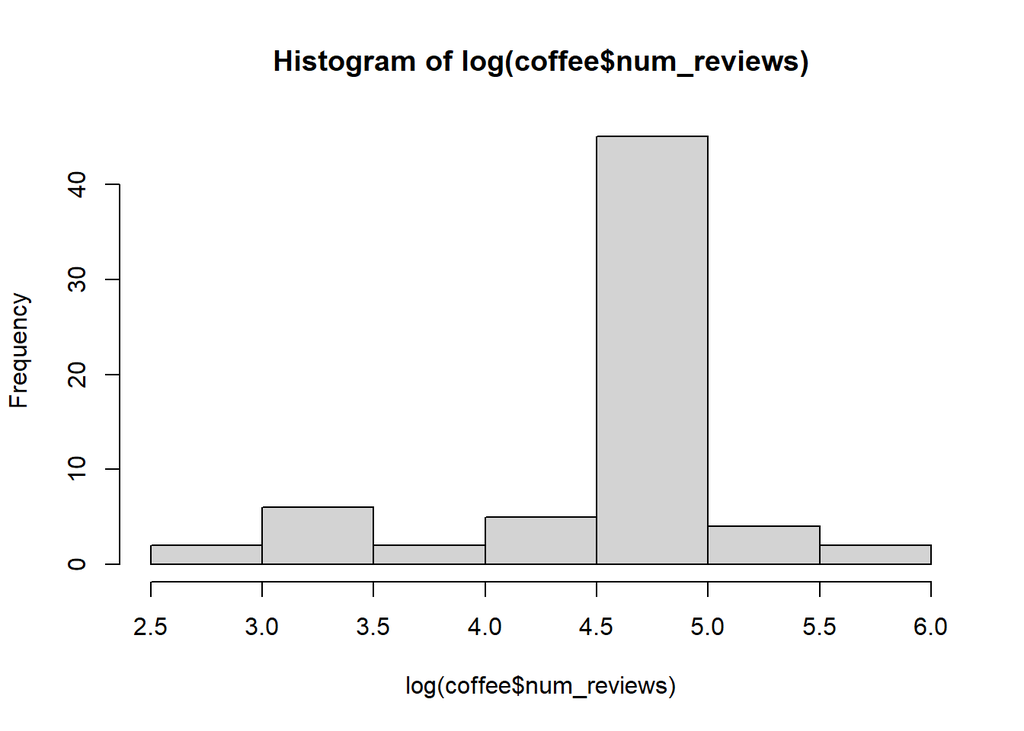

```r
hist(log(coffee$num_reviews))
```

```r
log(coffee$num_reviews)
```

```
##  [1] 3.496508 3.806662 3.332205 4.025352 2.772589 3.332205 4.043051 3.401197
##  [9] 4.605170 4.912655 4.143135 3.367296 4.644391 4.605170 4.605170 2.833213
## [17] 3.218876 4.219508 4.605170 4.543295 5.497168 4.605170 4.605170 4.605170
## [25] 4.605170 4.605170 4.330733 3.951244 5.298317 4.605170 4.605170 4.605170
## [33] 4.605170 4.605170 4.605170 4.605170 4.605170 5.298317 4.605170 4.605170
## [41] 4.605170 5.493061 4.605170 4.605170 4.605170 4.605170 4.584967 4.605170
## [49] 4.605170 4.605170 4.605170 4.605170 4.605170 4.605170 4.605170 4.605170
## [57] 4.605170 4.605170 4.605170 5.703782 5.991465 4.605170 4.605170 4.605170
## [65] 4.605170 4.605170     -Inf
```

```r
cor(coffee$num_reviews[-67], log(coffee$num_reviews)[-67])
```

```
## [1] 0.8672491
```

```r
wilcox.test(jitter(log(coffee$num_reviews), factor = .000001) ~ coffee$internet)
```

```
##
##  Wilcoxon rank sum exact test
##
## data:  jitter(log(coffee$num_reviews), factor = 1e-06) by coffee$internet
## W = 358, p-value = 0.01643
## alternative hypothesis: true location shift is not equal to 0
```

O Wilcoxon-Test para amostras dependentes aplica-se quando os grupos não são independentes e os pressupostos de normalidade estão violados. Para aplicar este teste apenas é necessário acrescentar o argumento **paired=TRUE** à função **wilcox.test()**.

```r
t.test(coffee$ratingMorning, coffee$ratingAfternoon, paired = TRUE)
```

```
##
##  Paired t-test
##
## data:  coffee$ratingMorning and coffee$ratingAfternoon
## t = 0.071529, df = 66, p-value = 0.9432
## alternative hypothesis: true difference in means is not equal to 0
## 95 percent confidence interval:
##  -0.0999019  0.1073260
## sample estimates:
## mean of the differences
##             0.003712062
```

```r
wilcox.test(coffee$ratingMorning, coffee$ratingAfternoon, paired = TRUE)
```

```
##
##  Wilcoxon signed rank test with continuity correction
##
## data:  coffee$ratingMorning and coffee$ratingAfternoon
## V = 1138, p-value = 0.9975
## alternative hypothesis: true location shift is not equal to 0
```

No exemplo anterior, os dois testes, paramétrico e não paramétrico, obtêm resultados semelhantes. Quando os pressuposto paramétricos são cumpridos é recomendada a utilização do t-test, uma vez que este teste é menos propenso a erro do tipo II (não rejeitando a h0 quando o deveria fazer – AKA falso negativo). Os testes não paramétricos devem estar reservados para situações em que os pressupostos de normalidade são manifestamente violados.

# 4. O “General Linear Model” (GLM)

Regressão e análise de variância e covariância são tradicionalmente apresentados como procedimentos estatísticos distintos. Esta distinção é meramente artificial, uma vez que todos este procedimentos derivam de um modelo teórico mais amplo denominado de General Linear Model (GLM). A grande maioria dos pacotes estatísticos operacionaliza os procedimentos de regressões e análises de variância de forma distinta para conveniência do utilizador e não porque exista uma diferença matemática entre eles. O GLM permite predizer ou estimar uma variável (variável dependente ou resposta) através de uma ou mais variáveis (variáveis independentes, preditoras ou explicativas). O GLM assume a seguinte fórmula geral:

Y = *(model)* + ε

$\hat{Yi}$ = β0 + β1X1i + β2X2i +…βkXki + ε; i = 1…n

A variável dependende (Y) é então predita por um conjunto de coeficientes (β1, β2… βk) que representam o peso de uma determinada variável independente (X1, X2…Xk) sobre a variável dependente. O GLM inclui ainda duas componentes adicionais, o intercept (representado por β0) e o erro (ou resíduo) (ε). O intercept da equação é uma constante matemática dependendo da escala das variáveis no modelo, enquanto que o erro (ou resíduo) consiste na diferença entre o valor observado na variável dependente para uma determinada observação e o valor da variável dependente estimado pelo modelo para essa mesma observação.

Neste contexto matemático é possível incluir no GLM variáveis independentes (VI) contínuas, fatores, bem como transformações (se não lineares) de VI. Habitualmente, quando as variáveis do GLM são contínuas falamos de regressões. Quando são fatores, falamos de ANOVA ou ANCOVA, caso também sejam incluídas covariáveis (variáveis contínuas) no modelo.

Em síntese, os três parâmetros fundamentais do GLM são:

> O intercept (β0) - que pode ser interpretado como o valor predito da VI quando todas as VD’s assumem o valor de 0  
> O(s) coeficiente(s) de regressão (β1, β2… βk) - Por exemplo β1 X1 pode ser interpretado como o valor de incremento na (VD) por cada unidade de incremento de X1, controlando estatisticamente todas as restantes variáveis no modelo (i.e., fixando os seus valores)  
> O erro (ε) ou variância residual do modelo

No caso específico da ANOVA e ANCOVA os parâmetros preconizados no GLM são incluidos através de um procedimento de recodificação dos níveis dos fatores, habitualmente denominado de codificação dummy. Assim, para um **fator com 3 níveis**, o GLM adquire a seguinte formula:

$\hat{Y}$ = α + β1X1+ β2X2 + ε

> X1 consiste no código dummy para o primeiro nível do fator. A observação neste nível recebe o valor de 1 para X1 ou de 0 quando assim não é;  
> X2 consiste no código dummy para o primeiro nível do fator. A observação neste nível recebe o valor de 1 para X2 ou de 0 quando assim não é;  
> O terceiro nível do fator é apenas predito pelo parameter α, que em termos práticos representa a sua média.

*Assim o valor predito para as diferentes níveis do fator são preditos da seguinte forma:*

> Y3 = α  
> Y2 = α + β2  
> Y1 = α + β1

O teste de significância para a ANOVA avalia simultaneamente em que medida β1 = 0 e β2 = 0.

O método mais frequente de estimação dos parâmetros do GLM é através do critério dos quadrados mínimos – ordinary least squares (OLS) criterion. Os detalhes matemáticos para aplicação deste método estão para além do âmbito deste curso. Importa no entanto referir que a utilização deste critério permite estimar o GLM considerando a diferença mínima possível entre os valores observados e os valores preditos pelo modelo (i.e. o erro do modelo).

# 5. Análise de regressão

Em termos gerais, a análise de regressão é utilizada para avaliar a relação entre uma ou mais VI’s contínuas e uma variável dependente. A criação de um modelo de regressão é frequentemente um processo complexo e interativo que se desenvolve em vários passos.  
Existem vários tipos específicos de regressão de tal forma que por vezes pode ser difícil perceber a que tipo de análise o termo “regressão” se refere.

| Tipo | Uso |
| --- | --- |
| Simple linear | Predição de uma VD quantitativa por uma VI quantitiva |
| Polynomial | Predição de uma VD quantitativa por uma VI quantitiva, quando a relação é polinomial |
| Multiple linear | Predição de uma VD quantitativa por duas ou mais VI’s |
| Multilevel | Predição de uma VD em dados hierárquicos |
| Multivariate | Predição de mais do que uma VD por uma ou mais VI’s |
| Logistic | Predição de uma VD categorrial por uma ou mais VI’s |
| Poisson | Predição de uma VD de contagens por uma ou mais VI’s |
| Cox proportional hazards | Predição do tempo para um evento por uma ou mais VI’s |
| Time-series | Modelação de time-series de dados com erros correlacionados |
| Nonlinear | Predição de mais do que uma VD por uma ou mais VI’s, quando a relação não é linear |
| Nonparametric | Predição de mais do que uma VD por uma ou mais VI’s, quando a formas de dados não especificadas previamente |
| Robust | Predição de mais do que uma VD por uma ou mais VI’s, utilizado uma abordagem robusta a observações influentes |

A grande quantidade de procedimentos de regressão e opções de análise disponíveis no R para estimação de modelos de regressão pode também suscitar alguma confusão. Neste link poderá encontrar uma lista exaustiva de funções do R que permitem estimar modelos de regressão.

No presente workshop a nossa incursão no mundo das regressão limita-se a apresentar e discutir a estimação do modelo de regressão linear simples. Este modelo permite avaliar a relação entre duas variáveis quantitativas. A correta estimação de modelos de regressão através do método OLS tem por base os seguintes pressupostos.

> **Normalidade** - A VD apresenta uma distribuição normal para valores fixos das VIs;  
> **Independência** - Os valores observados da VD são independentes;  
> **Linearidade** - A VD é uma função linear das VIs;  
> **Homocedasticidade** - A variância das VD não varia nos diferentes níveis das VIs (i.e., existe uma variância constante para os diferentes valores das VI).

A estimação de um modelo de regressão no R pode ser feita através da função **lm()**.

A fórmula do modelo permite utilizar um conjunto de outros símbolos com significado específico.

```r
knitr::kable(regsimbol, format = "markdown")
```

| símbolo | significado |
| --- | --- |
| ~ | Separa VI’s de VD’s |
| + | Separa VD’s |
| : | Define interação entre VD’s |
| * | Atalho para definir interações entre todas as VD’s do modelo (y ~ x * z * w <==> y ~ x + z + w + x:z + x:w + z:w + x:z:w) |
| ^ | Define interação a um nível específico ((y ~ x * z * w)^2 <==> y ~ x + z + w + x:z + x:w + z:w) |
| . | Define todas as variáveis da DF como VD’s |
| - | Remove uma variável da equação ((y ~ x * z * w)^2 - x:w <==> y ~ x + z + w + x:z + z:w) |
| -1 | Retira o intercept da equação, forçando a linha de regressão a cruzar origem em x=0 |
| I() | Elementos dentro dos parentesis são interpretrados de forma aritmética (y ~ x + I(x^2) tem como VD’s x e o quadrado de x |
| function | Funções matemáticas podem ser incorporadas no modelo (ex.: log() |

Após criação do modelo pela função lm(), existe um conjunto de funções disponibilizadas pelo R que podemos utilizar para clarificar diferentes aspetos dos modelo.

A denominação de regressão linear simples é aplicada quando o modelo criado incluí uma VI e uma VD.

```r
data(women)
str(women)
```

```
## 'data.frame':    15 obs. of  2 variables:
##  $ height: num  58 59 60 61 62 63 64 65 66 67 ...
##  $ weight: num  115 117 120 123 126 129 132 135 139 142 ...
```

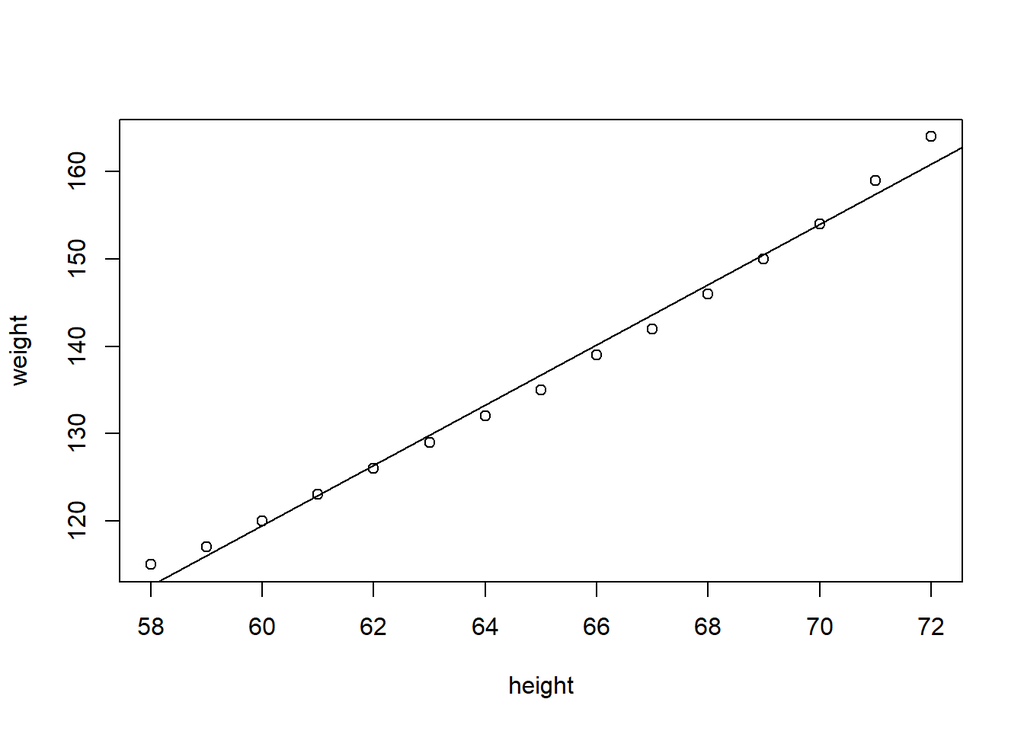

```r
plot(weight ~ height, data = women)
abline(lm(weight ~ height, data = women))
```

Para além da função **lm()** o R disponibiliza um conjunto de funções úteis quando produzimos estimamos modelos de regressão. Essas funções são aplicadas aos objetos produzidos pela função **lm()** permitindo retirar informação importante do modelo estimado

| fun | operation |
| --- | --- |
| summary() | apresenta resultados do modelo estimado |
| coefficients() | apresenta lista de coeficientes estimados |
| confint() | apresenta intervalos de confiança para os parâmetros estimados |
| fitted() | apresenta lista com valores estimados do modelo |
| residuals() | apresenta lista com valores dos resíduos |
| anova() | apresenta tabela anova para modelo e permite compara dois ou mais modelos ajustados |
| vcov() | apresenta matriz de covariâncias para parâmetros do modelo |
| AIC() | Apresenta valor de AIC para modelo |
| plot() | apresenta gráficos para diagnóstico e avaliação do modelo |
| predict() | apresenta estimativas do modelo |

## Modelos de regressão linear simples (preditor único)

```r
names(coffee)
```

```
##  [1] "coffee_shop_name" "cityarea"         "num_reviews"      "popular"
##  [5] "rating"           "ratingMorning"    "ratingLunch"      "ratingAfternoon"
##  [9] "ratingDinner"     "coffee"           "coffee_rec"       "tea"
## [13] "tea_rec"          "food"             "food_rec"         "alcohol"
## [17] "alcohol_rec"      "vibe"             "vibe_rec"         "service"
## [21] "service_rec"      "price"            "price_rec"        "convenience"
## [25] "convenience_rec"  "internet"         "seating"
```

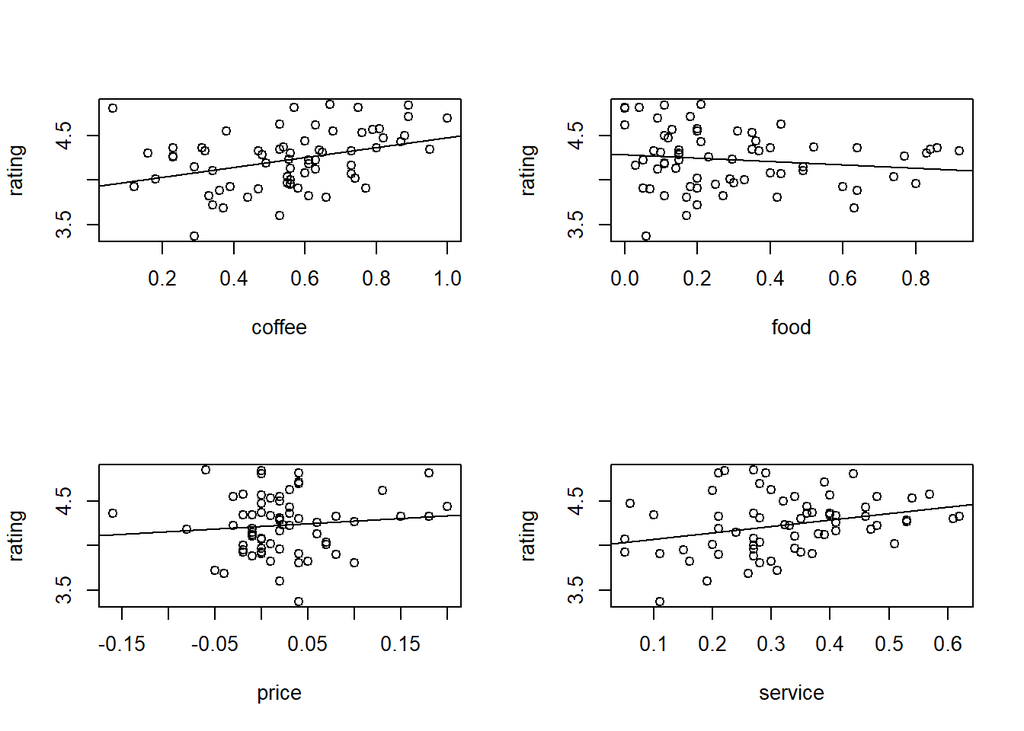

```r
par(mfrow=c(2,2))

plot(rating ~ coffee, data = coffee)
abline(lm(rating ~ coffee, data = coffee))

plot(rating ~ food, data = coffee)
abline(lm(rating ~ food, data = coffee))

plot(rating ~ price, data = coffee)
abline(lm(rating ~ price, data = coffee))

plot(rating ~ service, data = coffee)
abline(lm(rating ~ service, data = coffee))
```

```r
dev.off()
```

```r
model1 <-  lm(rating ~ coffee, data = coffee)
summary(model1)
```

```
##
## Call:
## lm(formula = rating ~ coffee, data = coffee)
##
## Residuals:
##      Min       1Q   Median       3Q      Max
## -0.71654 -0.24034  0.00022  0.20707  0.85037
##
## Coefficients:
##             Estimate Std. Error t value Pr(>|t|)
## (Intercept)   3.9265     0.1046  37.524  < 2e-16 ***
## coffee        0.5518     0.1764   3.128  0.00263 **
## ---
## Signif. codes:  0 '***' 0.001 '**' 0.01 '*' 0.05 '.' 0.1 ' ' 1
##
## Residual standard error: 0.305 on 65 degrees of freedom
## Multiple R-squared:  0.1309, Adjusted R-squared:  0.1175
## F-statistic: 9.786 on 1 and 65 DF,  p-value: 0.002631
```

```r
confint(model1)
```

```
##                 2.5 %    97.5 %
## (Intercept) 3.7175445 4.1355105
## coffee      0.1995199 0.9040276
```

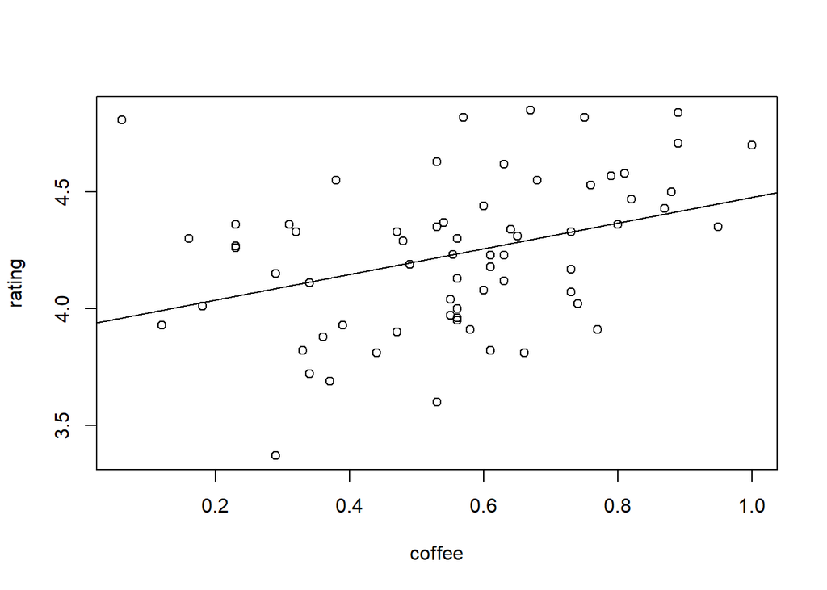

```r
plot(rating ~ coffee, data = coffee)
abline(lm(rating ~ coffee, data = coffee))
```

Numa regressão (ou ANOVA) o modelo é estimado com base nos dados observados, permitindo predizer os resultados na população. Para estimar o modelo de regressão simples são calculados 3 indicadores essenciais:

> Total sums of squares (SStotal) (~variância)  
> Residual sums of squares (SSresidual) (variância não explicada pelo model)  
> Model sums of squares (SSmodel) (SStotal - SSresidual)

Estes indicadores servem de base ao cálculo de indicadores adicionais que nos ajudam a perceber a qualidade do nosso modelo, nomeadamente, a média dos quadrados, RSE, F-value e R2. Em termos gerais, SStotal, a SSresidual e a Ssmodel são calculados com base nos quadrados dos resíduoes avaliam o quão bem o modelo descreve os nossos dados.